# Gun Violence Data Analysis

Steve Meadows

2024-07-24

# 1 Introduction

## 1.1 Description

Information on instances of gun violence documented in the United States from January 2013 through March 2018. Note that gun violence incidents in 2013 are not all included, with only 279 incidents from 2013 in this data set, notably missing the Las Vegas Mass Shooting. The data is contained in gunViolenceGeo.csv.

## 1.2 Source

Data was obtained from the GitHub repo https://github.com/jamesqo/gun-violence-data, which originally obtained the data from the Gun Violence Archive’s website. From the organization’s description:

## 1.3 Source description

Gun Violence Archive (GVA) is a not for profit corporation formed in 2013 to provide free online public access to accurate information about gun-related violence in the United States. GVA will collect and check for accuracy, comprehensive information about gun-related violence in the U.S. and then post and disseminate it online.

Although there are possible limitations in its comprehensiveness, research supports the utility of the data provided by the Gun Violence Archive for public health research and quantifying the amount of gun violence occurring throughout the United States.

## 1.4 Load R Packages

```r
library(tidyverse)
library(gapminder)
library(skimr)
library(ggthemes)
library(flextable)
library(dplyr)
library(naniar)
library(lubridate)
library(tidyr)
library(sf)
library(mapview)
library(maps)
library(naniar)
library(plotly)
library(ggpubr)
library(ggcorrplot)
library(scales)
library(tidymodels)
library(car)
library(infer)
library(htmltools)
library(leaflet)
```

## 1.5 Importing data

```r
gunViolence <- read_csv("gunViolenceGeo.csv")
census_df <- read_csv("https://raw.githubusercontent.com/dilernia/STA418-518/main/Data/census_data_state_2008-2021.csv")
county_census_df <- read_csv(
  "https://raw.githubusercontent.com/dilernia/STA418-518/main/Data/census_data_county_2009-2021.csv")
```

# 2 Gun Violence Data Dictionary

```r
# Create the data dictionary
dataDictionary <- tibble(
  Variable = colnames(gunViolence),
  Description = c(
    "Geographic ID",
    "gunviolencearchive.org ID for incident",
    "date of occurrence",
    "state",
    "city or county",
    "address where incident took place",
    "number of people killed",
    "number of people injured",
    "link to gunviolencearchive.org webpage containing details of incident",
    "link to online news story concerning incident",
    "ignore, always False",
    "congressional district",
    "key: gun ID, value: 'Unknown' or 'Stolen'",
    "key: gun ID, value: description of gun type",
    "list of incident characteristics",
    "latitude",
    "description of location where incident took place",
    "longitude",
    "number of guns involved",
    "additional notes about the incident",
    "key: participant ID",
    "key: participant ID, value: description of age group, e.g. 'Adult 18+'",
    "key: participant ID, value: 'Male' or 'Female'",
    "key: participant ID",
    "key: participant ID, value: relationship of participant to other participants",
    "key: participant ID, value: 'Arrested', 'Killed', 'Injured', or 'Unharmed'",
    "key: participant ID, value: 'Victim' or 'Subject-Suspect'",
    "links to online news stories concerning incident",
    "state house district",
    "state senate district",
    "full address where incident took place"
  ),
  Type = map_chr(gunViolence, .f = function(x) { typeof(x)[1] }),
  Class = map_chr(gunViolence, .f = function(x) { class(x)[1] })
)

# Print the data dictionary
data_dict_ft <-flextable(dataDictionary) |>
  add_header_row(values = "Table 1: Data Dictionary", colwidths = 4) |>
  padding(padding = 3, part = "all") |>
  add_footer_lines(values = "Source: Gun Violence Archive") |>
  set_table_properties(width = 1, layout = "autofit")|>
  colformat_double(j = 2:4, digits = 2) |>
  theme_vanilla() |>
  autofit()

data_dict_ft
```

| Table 1: Data Dictionary Variable | Table 1: Data Dictionary Description | Table 1: Data Dictionary Type | Table 1: Data Dictionary Class |
| --- | --- | --- | --- |
| geoid | Geographic ID | character | character |
| incident_id | gunviolencearchive.org ID for incident | double | numeric |
| date | date of occurrence | double | Date |
| state | state | character | character |
| city_or_county | city or county | character | character |
| address | address where incident took place | character | character |
| n_killed | number of people killed | double | numeric |
| n_injured | number of people injured | double | numeric |
| incident_url | link to gunviolencearchive.org webpage containing details of incident | character | character |
| source_url | link to online news story concerning incident | character | character |
| incident_url_fields_missing | ignore, always False | logical | logical |
| congressional_district | congressional district | double | numeric |
| gun_stolen | key: gun ID, value: 'Unknown' or 'Stolen' | character | character |
| gun_type | key: gun ID, value: description of gun type | character | character |
| incident_characteristics | list of incident characteristics | character | character |
| lat | latitude | double | numeric |
| location_description | description of location where incident took place | character | character |
| long | longitude | double | numeric |
| n_guns_involved | number of guns involved | double | numeric |
| notes | additional notes about the incident | character | character |
| participant_age | key: participant ID | character | character |
| participant_age_group | key: participant ID, value: description of age group, e.g. 'Adult 18+' | character | character |
| participant_gender | key: participant ID, value: 'Male' or 'Female' | character | character |
| participant_name | key: participant ID | character | character |
| participant_relationship | key: participant ID, value: relationship of participant to other participants | character | character |
| participant_status | key: participant ID, value: 'Arrested', 'Killed', 'Injured', or 'Unharmed' | character | character |
| participant_type | key: participant ID, value: 'Victim' or 'Subject-Suspect' | character | character |
| sources | links to online news stories concerning incident | character | character |
| state_house_district | state house district | double | numeric |
| state_senate_district | state senate district | double | numeric |
| address_full | full address where incident took place | character | character |

Source: Gun Violence Archive

## 2.1 Exploring high level data characteristics

```r
skim(gunViolence)
```

Data summary

| Name | gunViolence |
| --- | --- |
| Number of rows | 239677 |
| Number of columns | 31 |
| _______________________ |  |
| Column type frequency: |  |
| character | 20 |
| Date | 1 |
| logical | 1 |
| numeric | 9 |
| ________________________ |  |
| Group variables | None |

**Variable type: character**

| skim_variable | n_missing | complete_rate | min | max | empty | n_unique | whitespace |
| --- | --- | --- | --- | --- | --- | --- | --- |
| geoid | 8025 | 0.97 | 5 | 5 | 0 | 2821 | 0 |
| state | 0 | 1.00 | 4 | 20 | 0 | 51 | 0 |
| city_or_county | 0 | 1.00 | 3 | 46 | 0 | 12821 | 0 |
| address | 16497 | 0.93 | 2 | 97 | 0 | 197115 | 0 |
| incident_url | 0 | 1.00 | 48 | 50 | 0 | 239677 | 0 |
| source_url | 468 | 1.00 | 2 | 255 | 0 | 213974 | 0 |
| gun_stolen | 99498 | 0.58 | 8 | 5488 | 0 | 349 | 0 |
| gun_type | 99451 | 0.59 | 5 | 5488 | 0 | 2502 | 0 |
| incident_characteristics | 326 | 1.00 | 8 | 761 | 0 | 18126 | 0 |
| location_description | 197588 | 0.18 | 1 | 100 | 0 | 27605 | 0 |
| notes | 81017 | 0.66 | 1 | 261 | 0 | 136435 | 0 |
| participant_age | 92298 | 0.61 | 3 | 517 | 0 | 18951 | 0 |
| participant_age_group | 42119 | 0.82 | 11 | 1536 | 0 | 898 | 0 |
| participant_gender | 36362 | 0.85 | 6 | 803 | 0 | 873 | 0 |
| participant_name | 122253 | 0.49 | 4 | 2158 | 0 | 113402 | 0 |
| participant_relationship | 223903 | 0.07 | 8 | 366 | 0 | 284 | 0 |
| participant_status | 27626 | 0.88 | 8 | 1500 | 0 | 2150 | 0 |
| participant_type | 24863 | 0.90 | 8 | 1311 | 0 | 259 | 0 |
| sources | 609 | 1.00 | 8 | 3015 | 0 | 217280 | 0 |
| address_full | 7935 | 0.97 | 23 | 224 | 0 | 191632 | 0 |

**Variable type: Date**

| skim_variable | n_missing | complete_rate | min | max | median | n_unique |
| --- | --- | --- | --- | --- | --- | --- |
| date | 0 | 1 | 2013-01-01 | 2018-03-31 | 2016-04-05 | 1725 |

**Variable type: logical**

| skim_variable | n_missing | complete_rate | mean | count |
| --- | --- | --- | --- | --- |
| incident_url_fields_missing | 0 | 1 | 0 | FAL: 239677 |

**Variable type: numeric**

| skim_variable | n_missing | complete_rate | mean | sd | p0 | p25 | p50 | p75 | p100 | hist |
| --- | --- | --- | --- | --- | --- | --- | --- | --- | --- | --- |
| incident_id | 0 | 1.00 | 559334.35 | 293128.68 | 92114.00 | 308545.00 | 543587.00 | 817228.00 | 1083472.00 | ▇▇▆▆▆ |
| n_killed | 0 | 1.00 | 0.25 | 0.52 | 0.00 | 0.00 | 0.00 | 0.00 | 50.00 | ▇▁▁▁▁ |
| n_injured | 0 | 1.00 | 0.49 | 0.73 | 0.00 | 0.00 | 0.00 | 1.00 | 53.00 | ▇▁▁▁▁ |
| congressional_district | 11944 | 0.95 | 8.00 | 8.48 | 0.00 | 2.00 | 5.00 | 10.00 | 53.00 | ▇▂▁▁▁ |
| lat | 7923 | 0.97 | 37.55 | 5.13 | 19.11 | 33.90 | 38.57 | 41.44 | 71.34 | ▁▇▅▁▁ |
| long | 7923 | 0.97 | -89.34 | 14.36 | -171.43 | -94.16 | -86.25 | -80.05 | 97.43 | ▁▇▁▁▁ |
| n_guns_involved | 99451 | 0.59 | 1.37 | 4.68 | 1.00 | 1.00 | 1.00 | 1.00 | 400.00 | ▇▁▁▁▁ |
| state_house_district | 38772 | 0.84 | 55.45 | 42.05 | 1.00 | 21.00 | 47.00 | 84.00 | 901.00 | ▇▁▁▁▁ |
| state_senate_district | 32335 | 0.87 | 20.48 | 14.20 | 1.00 | 9.00 | 19.00 | 30.00 | 94.00 | ▇▆▂▁▁ |

# 3 Data Cleaning

I wanted to start pruning the data by starting with the most relevant and complete data. As stated in the description, the data is incomplete for the years 2013 and 2018. I proceeded to filter the data for the four years in between. Additionally, I made the data easier to work with by converting dates to datetime to extract chronological information.

```r
# Extract the year from the date column using stringr
gunViolence <- gunViolence |>
  mutate(year = as.integer(str_sub(date, 1, 4)))

# Filter data for the years 2014 to 2017
gunViolence <- gunViolence |>
  filter(year >= 2014 & year <= 2017)

# Change date column to datetime
gunViolence <- gunViolence |>
  mutate(date = as.Date(date, format = "%Y-%m-%d"))

# Extract the year and month from the date column
gunViolence <- gunViolence |>
  mutate(
    month = format(date, "%m")
  )

# Use stringr to remove text within parentheses in the city_or_county column
gunViolence <- gunViolence |>
  mutate(city_or_county = str_replace_all(city_or_county, "\\s*\\([^\\)]+\\)", ""))

# Trim any leading or trailing whitespace
gunViolence <- gunViolence |>
  mutate(city_or_county = str_trim(city_or_county))
```

## 3.1 Data Missingness

### 3.1.1 Plotting missingness for all data features

I began by examining the null values within the data and how to address them. Given the robust amount of information provided about these gun violence incidents, as well as the other datasets available to me regarding U.S. census data at the county, city, and state levels, I knew that location variables were important. I plotted all missing data and then visualized the missingness in relation to location.

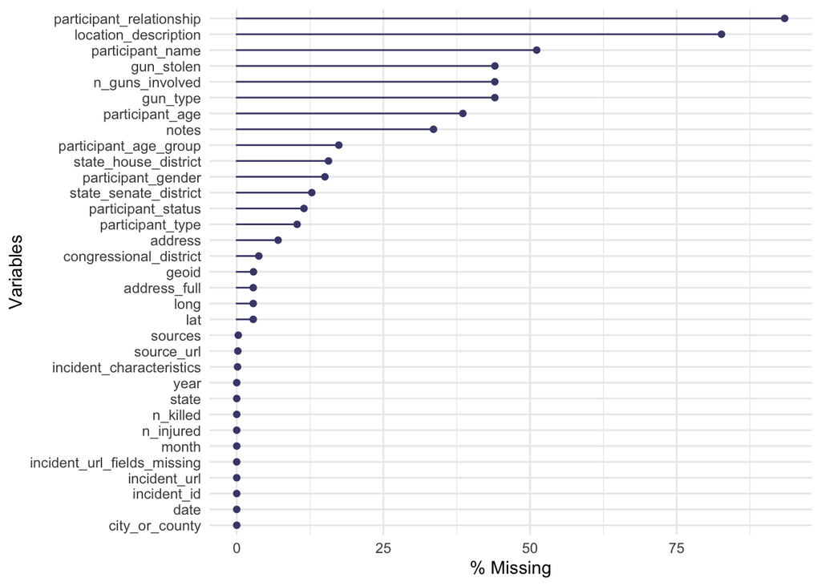

```r
gg_miss_var(gunViolence, show_pct = TRUE)
```

## 3.2 Plotting geolocation feature missingness

This visualization provides a closer look at location-level information by state. After creating the heatmap to observe the percentage of rows with null location information, I observed that missing `lat` and `long` coordinates were part and parcel to missing `geoid` values, which are extremely salient for analysis. This may suggest that these states weren’t as diligent in capturing that kind of data, or were negligent. States that were pushing the upper bounds of location missingness proportions were:

- Idaho
- Indiana
- South Dakota
- Virginia
- West Virginia

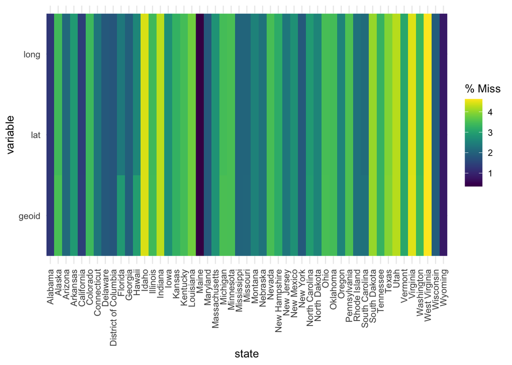

```r
gunViolence |>
  dplyr::select(
    geoid,
    lat,
    long,
    state
  ) |>
  gg_miss_fct(fct = state) +
  theme(axis.text.x = element_text(angle = 90, hjust = 1, vjust = 0.5))
```

## 3.3 Addressing important missing `geoid` data

To address geoid missingness, I compared incidents without IDs to ones that had them, by city, state, and year. If they were the same, I copied the geoid over and merged it back into the dataset. Here is an an examination of missingness after the merge. Here we can see that we went from over 8,000 missing `geoid` values to 443 and a completeness rate of 99.8% for the variable.

```r
# Identify rows with missing geoid
missing_geoid <- gunViolence |>
  filter(is.na(geoid))

# Identify rows with non-missing geoid
non_missing_geoid <- gunViolence |>
  filter(!is.na(geoid)) |>
  group_by(state, city_or_county, year) |>
  summarise(geoid = first(geoid), .groups = 'drop')

# Perform the matching and fill in the missing geoid values
filled_data <- missing_geoid |>
  left_join(non_missing_geoid, by = c("state", "city_or_county", "year")) |>
  mutate(geoid = if_else(is.na(geoid.x), geoid.y, geoid.x)) |>
  select(-geoid.x, -geoid.y)

# Combine the filled rows with the original data excluding the previously missing rows
final_data <- gunViolence |>
  filter(!is.na(geoid)) |>
  bind_rows(filled_data)

skim(final_data$geoid)
```

Data summary

| Name | final_data$geoid |
| --- | --- |
| Number of rows | 225597 |
| Number of columns | 1 |
| _______________________ |  |
| Column type frequency: |  |
| character | 1 |
| ________________________ |  |
| Group variables | None |

**Variable type: character**

| skim_variable | n_missing | complete_rate | min | max | empty | n_unique | whitespace |
| --- | --- | --- | --- | --- | --- | --- | --- |
| data | 443 | 1 | 5 | 5 | 0 | 2800 | 0 |

## 3.4 Reviewing missingness after cleaning

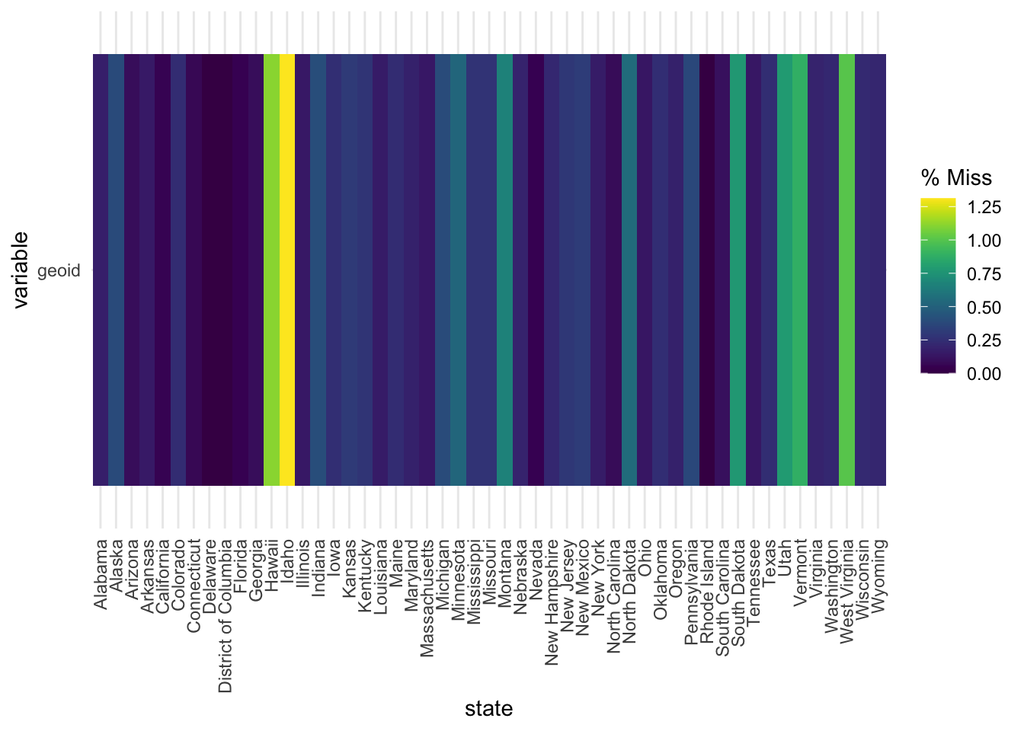

```r
final_data |>
  dplyr::select(
    geoid,
    state
  ) |>
  gg_miss_fct(fct = state) +
  theme(axis.text.x = element_text(angle = 90, hjust = 1, vjust = 0.5))
```

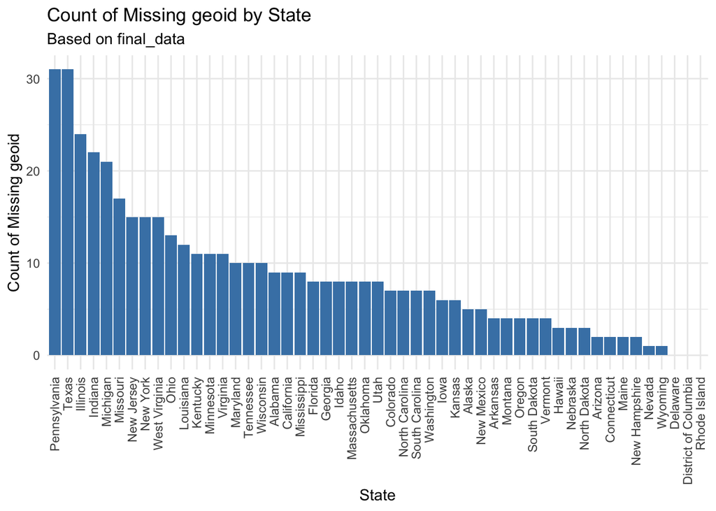

```r
# Calculate count of missing values for each state
missing_counts <- final_data |>
  dplyr::select(geoid, state) |>
  group_by(state) |>
  summarise(missing_count = sum(is.na(geoid))) |>
  ungroup()

# Create a bar plot to show the count of missing values
ggplot(missing_counts, aes(x = reorder(state, -missing_count), y = missing_count)) +
  geom_bar(stat = "identity", fill = "steelblue") +
  theme_minimal() +
  theme(axis.text.x = element_text(angle = 90, hjust = 1, vjust = 0.5)) +
  labs(
    x = "State",
    y = "Count of Missing geoid",
    title = "Count of Missing geoid by State",
    subtitle = "Based on final_data"
  )
```

## 3.5 Missingness Reflection

My method of matching locations from the same year to cross-reference geographical IDs worked to reduce the number of missing values. As we can see, the highest numbers of null values exist in high-incident states. In the scheme of things, this should not significantly affect the accuracy of our data.

# 4 EDA

## 4.1 Country Wide Year-level Summary Statistics

```r
# Calculate the count of incidents per year
yearly_counts <- final_data |>
  group_by(year) |>
  summarise(
    incidents = n(),
    n_killed = sum(n_killed),
    n_injured = sum(n_injured)
  )

# Convert the year column to a character to avoid comma formatting
yearly_counts$year <- as.character(yearly_counts$year)

# Display the yearly counts using flextable
yearly_counts_ft <- yearly_counts |>
  flextable() |>
  set_header_labels(
    year = "Year",
    incidents = "Incidents",
    n_killed = "Killed",
    n_injured = "Injured"
  ) |>
  add_header_row(
    values = "Table 2: Aggregate Sum of U.S. Gun Violence Incidents, Deaths, and Injuries per Year",
    colwidths = 4
  ) |>
  padding(padding = 3, part = "all") |>
  theme_vanilla() |>
  autofit()

# Print the flextable
yearly_counts_ft
```

| Table 2: Aggregate Sum of U.S. Gun Violence Incidents, Deaths, and Injuries per Year Year | Table 2: Aggregate Sum of U.S. Gun Violence Incidents, Deaths, and Injuries per Year Incidents | Table 2: Aggregate Sum of U.S. Gun Violence Incidents, Deaths, and Injuries per Year Killed | Table 2: Aggregate Sum of U.S. Gun Violence Incidents, Deaths, and Injuries per Year Injured |
| --- | --- | --- | --- |
| 2014 | 51,854 | 12,557 | 23,002 |
| 2015 | 53,579 | 13,484 | 26,967 |
| 2016 | 58,763 | 15,066 | 30,580 |
| 2017 | 61,401 | 15,511 | 30,703 |

## 4.2 Country Wide Year-level Summary Statistics

```r
# Calculate summary statistics for incidents, n_killed, and n_injured per year
summary_year <- yearly_counts |>
  reframe(
    Statistic = c("Minimum", "Q1", "Median", "Mean (μ)", "Q3", "Maximum", "SD (σ)"),
    Incidents = c(
      min(incidents, na.rm = TRUE),
      quantile(incidents, 0.25, na.rm = TRUE),
      median(incidents, na.rm = TRUE),
      mean(incidents, na.rm = TRUE),
      quantile(incidents, 0.75, na.rm = TRUE),
      max(incidents, na.rm = TRUE),
      sd(incidents, na.rm = TRUE)
    ),
    Killed = c(
      min(n_killed, na.rm = TRUE),
      quantile(n_killed, 0.25, na.rm = TRUE),
      median(n_killed, na.rm = TRUE),
      mean(n_killed, na.rm = TRUE),
      quantile(n_killed, 0.75, na.rm = TRUE),
      max(n_killed, na.rm = TRUE),
      sd(n_killed, na.rm = TRUE)
    ),
    Injured = c(
      min(n_injured, na.rm = TRUE),
      quantile(n_injured, 0.25, na.rm = TRUE),
      median(n_injured, na.rm = TRUE),
      mean(n_injured, na.rm = TRUE),
      quantile(n_injured, 0.75, na.rm = TRUE),
      max(n_injured, na.rm = TRUE),
      sd(n_injured, na.rm = TRUE)
    )
  ) |>
  mutate_if(is.numeric, round, digits = 2)

summary_year_ft <- flextable(summary_year) |>
  add_header_row(values = "Table 3: U.S. Summary Statistics of Gun Violence Incidents, Deaths, and Injuries per Year (2014-2017)", colwidths = 4) |>
  padding(padding = 3, part = "all") |>
  add_footer_lines(values = "Source: Gun Violence Archive") |>
  colformat_double(j = 2:4, digits = 2)|>
  theme_vanilla() |>
  autofit()


summary_year_ft
```

| Table 3: U.S. Summary Statistics of Gun Violence Incidents, Deaths, and Injuries per Year (2014-2017) Statistic | Table 3: U.S. Summary Statistics of Gun Violence Incidents, Deaths, and Injuries per Year (2014-2017) Incidents | Table 3: U.S. Summary Statistics of Gun Violence Incidents, Deaths, and Injuries per Year (2014-2017) Killed | Table 3: U.S. Summary Statistics of Gun Violence Incidents, Deaths, and Injuries per Year (2014-2017) Injured |
| --- | --- | --- | --- |
| Minimum | 51,854.00 | 12,557.00 | 23,002.00 |
| Q1 | 53,147.75 | 13,252.25 | 25,975.75 |
| Median | 56,171.00 | 14,275.00 | 28,773.50 |
| Mean (μ) | 56,399.25 | 14,154.50 | 27,813.00 |
| Q3 | 59,422.50 | 15,177.25 | 30,610.75 |
| Maximum | 61,401.00 | 15,511.00 | 30,703.00 |
| SD (σ) | 4,442.89 | 1,375.08 | 3,645.54 |

Source: Gun Violence Archive

Here are the statistical summary statistics for our gun violence incidents for the entire US for our years of concern.

## 4.3 Visualization: Histogram of Monthly Incidents per Year

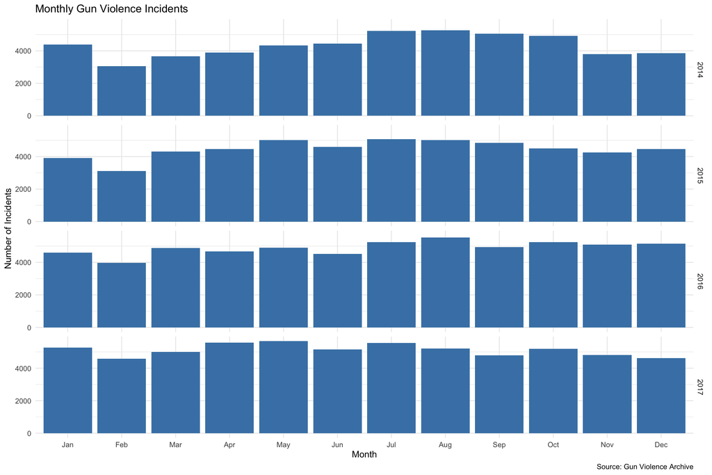

```r
# Create the faceted histogram
ggplot(final_data, aes(x = month)) +
  geom_histogram(stat = "count", fill = "steelblue") +
  facet_grid(year ~ .) +
  labs(
    title = "Monthly Gun Violence Incidents",
    x = "Month",
    y = "Number of Incidents",
    caption = "Source: Gun Violence Archive"
  ) +
  theme_minimal() +
  scale_x_discrete(labels = month.abb)  # Use abbreviated month names
```

I next broke each year of gun violence incidents down by month. An interesting trend emerges with this histogram. With the exception of a peak in incidents in January, we notice that incidents start to increase as the warmer months approach.

## 4.4 Gun Violence - State Level

I began analyzing this data by examining gun violence at the state level for the most recent year, as 2017 has the highest number of incidents.

### 4.4.1 State-level Summary Statistics for Top 15 States

```r
# Summarize the number of incidents per state
state_counts_all_years <- final_data |>
  filter(state != "District of Columbia") |>
  group_by(state, year) |>
  summarise(
    count = n(),
    n_killed = sum(n_killed),
    n_injured = sum(n_injured)
    ) |>
  arrange(desc(count))

# Calculate the average count for each state over all years
state_avg_counts <- state_counts_all_years %>%
  group_by(state) %>%
  summarize(avg_count = mean(count, na.rm = TRUE)) %>%
  arrange(desc(avg_count))

# Select the top 15 states by average count
top_15_states <- state_avg_counts %>% slice(1:15)

# Filter the original data for these top 15 states
top_15_data <- state_counts_all_years %>% filter(state %in% top_15_states$state)

# Generate the summary statistics for each of the top 15 states
summary_stats <- top_15_data %>%
  group_by(state) %>%
  summarize(
    min_count = min(count, na.rm = TRUE),
    q1_count = quantile(count, 0.25, na.rm = TRUE),
    median_count = median(count, na.rm = TRUE),
    mean_count = mean(count, na.rm = TRUE),
    q3_count = quantile(count, 0.75, na.rm = TRUE),
    max_count = max(count, na.rm = TRUE),
    sd_count = sd(count, na.rm = TRUE),
    min_killed = min(n_killed, na.rm = TRUE),
    q1_killed = quantile(n_killed, 0.25, na.rm = TRUE),
    median_killed = median(n_killed, na.rm = TRUE),
    mean_killed = mean(n_killed, na.rm = TRUE),
    q3_killed = quantile(n_killed, 0.75, na.rm = TRUE),
    max_killed = max(n_killed, na.rm = TRUE),
    sd_killed = sd(n_killed, na.rm = TRUE),
    min_injured = min(n_injured, na.rm = TRUE),
    q1_injured = quantile(n_injured, 0.25, na.rm = TRUE),
    median_injured = median(n_injured, na.rm = TRUE),
    mean_injured = mean(n_injured, na.rm = TRUE),
    q3_injured = quantile(n_injured, 0.75, na.rm = TRUE),
    max_injured = max(n_injured, na.rm = TRUE),
    sd_injured = sd(n_injured, na.rm = TRUE)
  )

# Round all summary statistics
summary_stats <- summary_stats %>%
  mutate(across(where(is.numeric), round, digits = 0))

# Split the summary statistics into three different data frames
summary_incidents <- summary_stats %>%
  select(state, min_count, q1_count, median_count, mean_count, q3_count, max_count, sd_count)

summary_killed <- summary_stats %>%
  select(state, min_killed, q1_killed, median_killed, mean_killed, q3_killed, max_killed, sd_killed)

summary_injured <- summary_stats %>%
  select(state, min_injured, q1_injured, median_injured, mean_injured, q3_injured, max_injured, sd_injured)

# Convert each summary statistics data frame to a flextable
ft_incidents <- flextable(summary_incidents) %>%
  set_header_labels(
    state = "State",
    min_count = "Min Incident", q1_count = "Q1 Incident", median_count = "Median Incident",
    mean_count = "Mean Incident", q3_count = "Q3 Incident", max_count = "Max Incident",
    sd_count = "SD Incident"
  ) %>%
  add_header_row(values = "Table 4a: Summary Statistics of Gun Violence Incidents by state (2017)", colwidths = 8) %>%
  padding(padding = 3, part = "all") %>%
  add_footer_lines(values = "Source: Gun Violence Archive") %>%
  theme_vanilla() %>%
  autofit()

ft_killed <- flextable(summary_killed) %>%
  set_header_labels(
    state = "State",
    min_killed = "Min Killed", q1_killed = "Q1 Killed", median_killed = "Median Killed",
    mean_killed = "Mean Killed", q3_killed = "Q3 Killed", max_killed = "Max Killed",
    sd_killed = "SD Killed"
  ) %>%
  add_header_row(values = "Table 4b: Summary Statistics of Gun Violence Deaths by state (2017)", colwidths = 8) %>%
  padding(padding = 3, part = "all") %>%
  add_footer_lines(values = "Source: Gun Violence Archive") %>%
  theme_vanilla() %>%
  autofit()

ft_injured <- flextable(summary_injured) %>%
  set_header_labels(
    state = "State",
    min_injured = "Min Injured", q1_injured = "Q1 Injured", median_injured = "Median Injured",
    mean_injured = "Mean Injured", q3_injured = "Q3 Injured", max_injured = "Max Injured",
    sd_injured = "SD Injured"
  ) %>%
  add_header_row(values = "Table 4c: Summary Statistics of Gun Violence Injuries by state (2017)", colwidths = 8) %>%
  padding(padding = 3, part = "all") %>%
  add_footer_lines(values = "Source: Gun Violence Archive") %>%
  theme_vanilla() %>%
  autofit()

# Print the flextables
ft_incidents
```

[output not shown]

Source: Gun Violence Archive

```r
ft_killed
```

[output not shown]

Source: Gun Violence Archive

```r
ft_injured
```

[output not shown]

Source: Gun Violence Archive

### 4.4.2 Visualization: Bar graph of Incidents by state

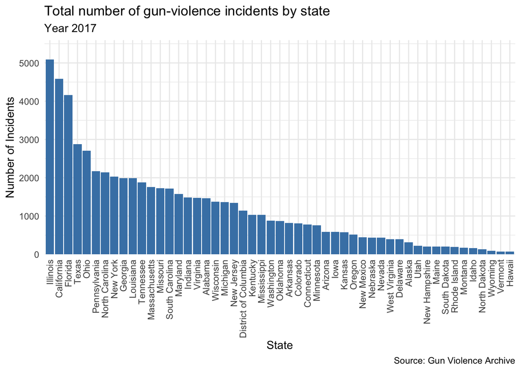

```r
# filtering for the year 2017
gun_data_2017 <- final_data |>
  filter(format(as.Date(date), "%Y") == "2017")

# Summarize the number of incidents per state
state_counts <- gun_data_2017 |>
  group_by(state) |>
  summarise(count = n()) |>
  arrange(desc(count))

# Convert the state column to a factor with levels ordered by count
gun_data_2017 <- gun_data_2017 |>
  mutate(state = factor(state, levels = state_counts$state))

gun_data_2017 |>
  ggplot(
    aes(
      x = state
    )
  ) +
  geom_bar(binwidth = 1, fill = "steelblue", boundary = 0) +
  scale_y_continuous(expand = expansion(mult = c(0,0.1))) +
  # scale_x_continuous(limits = c(0, 14), breaks = seq(0, 14, by = 2)) +
  labs(
    y = "Number of Incidents",
    x = "State",
    title = "Total number of gun-violence incidents by state",
    subtitle = "Year 2017",
    caption = "Source: Gun Violence Archive"
  ) +
  theme_minimal() +
  theme(
    axis.text.x = element_text(angle = 90, hjust = 1, vjust = 0.5)
  )
```

Looking at this initial visualization, we can see some staggering levels of gun violence in certain states. However, most of the states with high levels of gun violence are also some of the most densely populated in the country. I decided to analyze the same data while controlling for population.

### 4.4.3 Census Data Cleaning

```r
census_df <- census_df |>
  filter(year >= 2014, year <=2017)

# Filtering census data for 2017
census_df_2017 <- census_df |>
  filter(year == 2017)

# Aggregating population by state
census_df_2017_pop_by_state <- census_df_2017 |>
  group_by(county_state, year, geoid) |>
  summarise(population = sum(population), .groups = 'drop')
```

### 4.4.4 Examining high-level data characteristics

```r
skim(census_df)
```

Data summary

| Name | census_df |
| --- | --- |
| Number of rows | 208 |
| Number of columns | 26 |
| _______________________ |  |
| Column type frequency: |  |
| character | 2 |
| numeric | 24 |
| ________________________ |  |
| Group variables | None |

**Variable type: character**

| skim_variable | n_missing | complete_rate | min | max | empty | n_unique | whitespace |
| --- | --- | --- | --- | --- | --- | --- | --- |
| geoid | 0 | 1 | 2 | 2 | 0 | 52 | 0 |
| county_state | 0 | 1 | 4 | 20 | 0 | 52 | 0 |

**Variable type: numeric**

| skim_variable | n_missing | complete_rate | mean | sd | p0 | p25 | p50 | p75 | p100 | hist |
| --- | --- | --- | --- | --- | --- | --- | --- | --- | --- | --- |
| year | 0 | 1 | 2015.50 | 1.12 | 2014.00 | 2014.75 | 2015.50 | 2016.25 | 2017.00 | ▇▇▁▇▇ |
| population | 0 | 1 | 6263911.70 | 7109820.85 | 579315.00 | 1791128.50 | 4278116.50 | 7027585.00 | 39536653.00 | ▇▂▁▁▁ |
| median_income | 0 | 1 | 56577.62 | 11095.19 | 18626.00 | 49491.25 | 55088.00 | 63116.00 | 82372.00 | ▁▁▇▅▂ |
| median_monthly_rent_cost | 0 | 1 | 921.28 | 213.41 | 433.00 | 769.75 | 853.50 | 1049.50 | 1573.00 | ▁▇▅▂▁ |
| median_monthly_home_cost | 0 | 1 | 1057.44 | 344.69 | 251.00 | 826.25 | 968.00 | 1269.25 | 1977.00 | ▁▇▆▃▂ |
| prop_female | 0 | 1 | 0.51 | 0.01 | 0.47 | 0.50 | 0.51 | 0.51 | 0.53 | ▁▁▆▇▂ |
| prop_male | 0 | 1 | 0.49 | 0.01 | 0.47 | 0.49 | 0.49 | 0.50 | 0.53 | ▂▇▆▁▁ |
| prop_white | 0 | 1 | 0.76 | 0.13 | 0.25 | 0.68 | 0.78 | 0.85 | 0.95 | ▁▁▃▇▇ |
| prop_black | 0 | 1 | 0.11 | 0.11 | 0.00 | 0.03 | 0.08 | 0.16 | 0.49 | ▇▃▁▁▁ |
| prop_native | 0 | 1 | 0.02 | 0.03 | 0.00 | 0.00 | 0.00 | 0.01 | 0.15 | ▇▁▁▁▁ |
| prop_asian | 0 | 1 | 0.04 | 0.05 | 0.00 | 0.02 | 0.03 | 0.05 | 0.38 | ▇▁▁▁▁ |
| prop_hawaiin_islander | 0 | 1 | 0.00 | 0.01 | 0.00 | 0.00 | 0.00 | 0.00 | 0.10 | ▇▁▁▁▁ |
| prop_other_race | 0 | 1 | 0.03 | 0.03 | 0.00 | 0.01 | 0.02 | 0.05 | 0.17 | ▇▂▁▁▁ |
| prop_multi_racial | 0 | 1 | 0.03 | 0.03 | 0.01 | 0.02 | 0.03 | 0.03 | 0.24 | ▇▁▁▁▁ |
| prop_highschool | 0 | 1 | 0.24 | 0.04 | 0.15 | 0.22 | 0.24 | 0.26 | 0.35 | ▁▅▇▃▁ |
| prop_GED | 0 | 1 | 0.04 | 0.01 | 0.02 | 0.04 | 0.04 | 0.05 | 0.07 | ▃▇▆▃▂ |
| prop_some_college | 0 | 1 | 0.06 | 0.01 | 0.01 | 0.06 | 0.06 | 0.07 | 0.09 | ▁▁▇▇▂ |
| prop_college_no_degree | 0 | 1 | 0.15 | 0.02 | 0.09 | 0.13 | 0.15 | 0.16 | 0.21 | ▂▃▇▅▁ |
| prop_associates | 0 | 1 | 0.09 | 0.02 | 0.03 | 0.08 | 0.08 | 0.10 | 0.14 | ▁▂▇▃▁ |
| prop_bachelors | 0 | 1 | 0.19 | 0.03 | 0.12 | 0.17 | 0.19 | 0.21 | 0.26 | ▂▅▇▆▂ |
| prop_masters | 0 | 1 | 0.08 | 0.03 | 0.05 | 0.07 | 0.08 | 0.09 | 0.21 | ▇▅▁▁▁ |
| prop_professional | 0 | 1 | 0.02 | 0.01 | 0.01 | 0.02 | 0.02 | 0.02 | 0.08 | ▇▁▁▁▁ |
| prop_doctoral | 0 | 1 | 0.01 | 0.01 | 0.01 | 0.01 | 0.01 | 0.02 | 0.05 | ▇▂▁▁▁ |
| prop_poverty | 0 | 1 | 0.15 | 0.05 | 0.07 | 0.11 | 0.14 | 0.16 | 0.46 | ▇▅▁▁▁ |

### 4.4.5 Visualization: Bar Graph of Incidents by state per 100,000 people

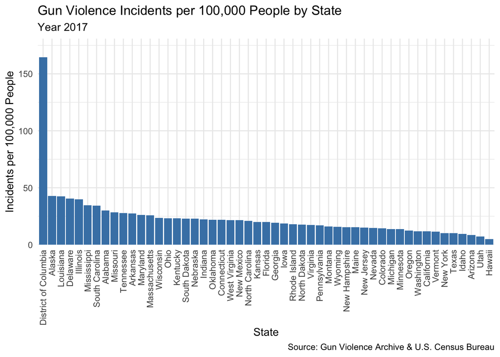

```r
# Summarize the number of incidents per state
state_counts <- gun_data_2017 |>
  group_by(state) |>
  summarise(count = n()) |>
  arrange(desc(count))

# Merge with population data
state_counts <- state_counts |>
  left_join(census_df_2017_pop_by_state, by = c("state" = "county_state"))

# Calculate incidents per 100,000 people
state_counts <- state_counts |>
  mutate(incidents_per_100k = (count / population) * 100000)

# Convert the state column to a factor with levels ordered by incidents_per_100k
state_counts <- state_counts |>
  mutate(state = factor(state, levels = state[order(incidents_per_100k, decreasing = TRUE)]))

# Create the bar chart
ggplot(state_counts, aes(x = state, y = incidents_per_100k)) +
  geom_bar(stat = "identity", fill = "steelblue") +
  scale_y_continuous(expand = expansion(mult = c(0, 0.1))) +
  labs(
    y = "Incidents per 100,000 People",
    x = "State",
    title = "Gun Violence Incidents per 100,000 People by State",
    subtitle = "Year 2017",
    caption = "Source: Gun Violence Archive & U.S. Census Bureau"
  ) +
  theme_minimal() +
  theme(
    axis.text.x = element_text(angle = 90, hjust = 1, vjust = 0.5)
  )
```

After controlling for population using the Census Bureau dataset, DC has the most gun violence incidents per 100,000 people in the country for this year. However, DC is not considered a state but a federal district, more like a city. For the sake of analyzing like for like, I will omit it from the analysis for now.

### 4.4.6 Visulization: Bar Graph of Incidents by state per 100,000 people - Removing DC

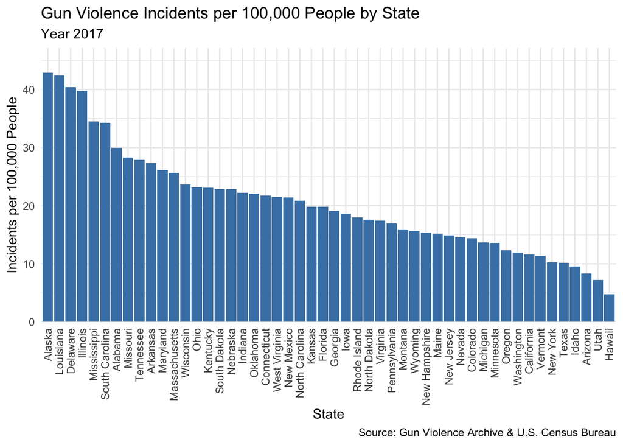

```r
# Summarize the number of incidents per state
state_counts <- gun_data_2017 |>
  filter(state != "District of Columbia") |>
  group_by(state) |>
  summarise(count = n()) |>
  arrange(desc(count))

# Merge with population data
state_counts <- state_counts |>
  left_join(census_df_2017_pop_by_state, by = c("state" = "county_state"))

# Calculate incidents per 100,000 people
state_counts <- state_counts |>
  mutate(incidents_per_100k = (count / population) * 100000)

# Convert the state column to a factor with levels ordered by incidents_per_100k
state_counts <- state_counts |>
  mutate(state = factor(state, levels = state[order(incidents_per_100k, decreasing = TRUE)]))

# Create the bar chart

ggplot(state_counts, aes(x = state, y = incidents_per_100k)) +
  geom_bar(stat = "identity", fill = "steelblue") +
  scale_y_continuous(expand = expansion(mult = c(0, 0.1))) +
  labs(
    y = "Incidents per 100,000 People",
    x = "State",
    title = "Gun Violence Incidents per 100,000 People by State",
    subtitle = "Year 2017",
    caption = "Source: Gun Violence Archive & U.S. Census Bureau"
  ) +
  theme_minimal() +
  theme(
    axis.text.x = element_text(angle = 90, hjust = 1, vjust = 0.5),
    legend.position = "none"
  )
```

After removing the District of Columbia, we get a better comparison between states. I was surprised to see Alaska taking the top spot. After some Google searching, I obtained records of gun ownership by state.

According to [World Population Review](https://worldpopulationreview.com/state-rankings/gun-ownership-by-state), gun ownership rates in Alaska are estimated to be 64.5%. This could potentially be a correlative factor in gun violence incidents within the state. It was also surprising to see Delaware above a state like Illinois, considering the anecdotes I’ve always heard regarding the violence in Chicago.

## 4.5 Visualization: Interactive Map of Incidents by State

Here I mapped out all 50 state’s level of incidents per 100,000 people onto a leaflet to highlight the most gun violence prone states in 2017.

```r
# Downloading state-level shape files from US Census Bureau
if(!file.exists("cb_2018_us_state_500k.zip")) {
download.file(url = "https://www2.census.gov/geo/tiger/GENZ2018/shp/cb_2018_us_state_500k.zip",
              destfile = "cb_2018_us_state_500k.zip")
}

# Create directory for geospatial files
if(!dir.exists("GeoFiles")) {
dir.create("GeoFiles")
}

# Unzipping files
utils::unzip("cb_2018_us_state_500k.zip",
             exdir = "GeoFiles")

# Loading the shapefiles
state_shape <- st_read("GeoFiles//cb_2018_us_state_500k.shp",
                       quiet = TRUE)

# Ensure the geoid column in state_counts is properly formatted as GEOID
state_counts <- state_counts |>
  mutate(GEOID = str_pad(geoid, width = 2, side = "left", pad = "0"))

# Merging state_counts with state_shape shapefile
state_shape_full <- state_shape |>
  left_join(state_counts, by = c("GEOID" = "GEOID"))

# Remove rows with NA values
cleaned_state_shape <- state_shape_full |>
  drop_na()

# Ensure cleaned_state_shape is an sf object if not already done
if (!inherits(cleaned_state_shape, "sf")) {
  cleaned_state_shape <- st_as_sf(cleaned_state_shape)
}

# Transform to WGS84 CRS to be compatible with leaflet
cleaned_state_shape <- st_transform(cleaned_state_shape, crs = 4326)

# Check for and handle missing values in key columns
cleaned_state_shape <- cleaned_state_shape |>
  filter(!is.na(state) & !is.na(population) & !is.na(count) & !is.na(incidents_per_100k))

# Defining pop-up labels
labels <- cleaned_state_shape |>
  mutate(labels = paste0(
    "<strong>", str_to_title(state), "</strong><br/>",
    "Population: ", population, "<br/>",
    "Incidents: ", count, "<br/>",
    "Incidents per 100k: ", round(incidents_per_100k, 2))) |>
  pull(labels) |>
  lapply(htmltools::HTML)

# Quantitative variable to color areal units (states) by
myVariable <- cleaned_state_shape$incidents_per_100k

# Defining nice cut points for coloring
bins <- seq(min(myVariable, na.rm = TRUE), max(myVariable, na.rm = TRUE), length.out = 6)

# Selecting color palette
pal <- colorBin("PuBu", domain = myVariable, bins = bins)

# Create the choropleth map
myLeaflet <- leaflet(cleaned_state_shape) |>
  setView(lng = -96, lat = 37.8, zoom = 2.4) |>
  addProviderTiles("OpenStreetMap.Mapnik",
                   options = providerTileOptions(
                     id = "mapbox.light",
                     accessToken = Sys.getenv('MAPBOX_ACCESS_TOKEN'))) |>
  addPolygons(
    fillColor = ~pal(myVariable),
    weight = 0.80,
    opacity = 1,
    color = "black",
    fillOpacity = 1,
    highlightOptions = highlightOptions(
      color = "#666"),
    label = labels,
    labelOptions = labelOptions(textsize = "15px")) |>
  addLegend(pal = pal,
            values = ~ myVariable,
            opacity = 0.7,
            title = "Gun Violence Incidents per 100k (2017)",
            position = "bottomright")

# Display the map
myLeaflet
```

[interactive chart not shown]

## 4.6 Visualization: Boxplot Showing Range of Incidents Per Year from 2014-2017

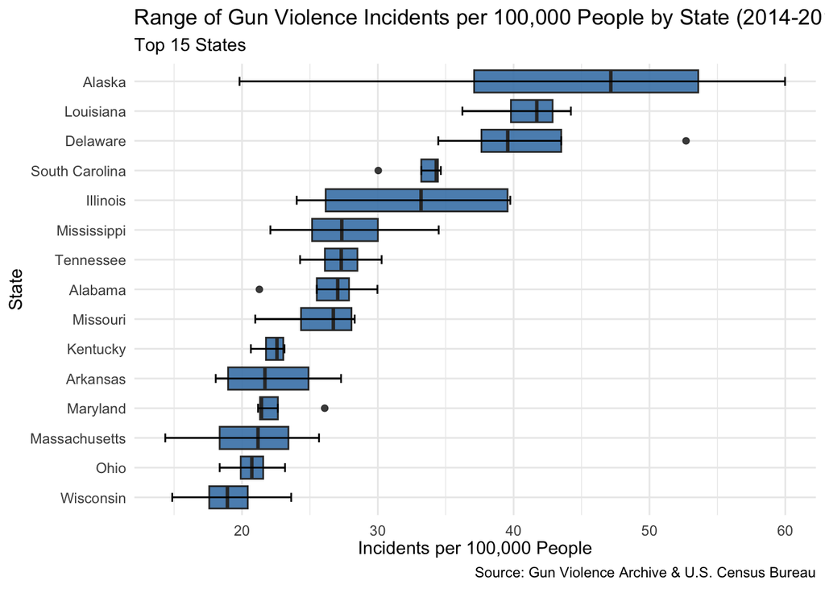

```r
# Arrange by incidents_per_100k in descending order and extract the top 15 states
top_15_states <- state_counts |>
  arrange(desc(incidents_per_100k)) |>
  slice(1:15) |>
  pull(state)

# Merge with population data
state_counts_all_years <- state_counts_all_years |>
  left_join(census_df, by = c("state" = "county_state",
                              "year" = "year"))

# Calculate incidents per 100,000 people
state_counts_all_years <- state_counts_all_years |>
  mutate(incidents_per_100k = (count / population) * 100000)

# Filter the state_counts_all_years DataFrame to include only the top 15 states
filtered_data <- state_counts_all_years |>
  filter(state %in% top_15_states)

# Create the box plot
ggplot(filtered_data, aes(x = fct_reorder(state, incidents_per_100k, .desc=FALSE ) , y = incidents_per_100k)) +
  geom_boxplot(fill = "steelblue", alpha = 0.9) +
  stat_boxplot(geom = "errorbar", width = 0.3, coef = 1.5) +
  labs(
    y = "Incidents per 100,000 People",
    x = "State",
    title = "Range of Gun Violence Incidents per 100,000 People by State (2014-2017)",
    subtitle = "Top 15 States",
    caption = "Source: Gun Violence Archive & U.S. Census Bureau"
  ) +

  coord_flip() +
  theme_minimal() +
  theme(
    axis.text.x = element_text(hjust = .5, vjust = 0.5)
  )
```

Here we can see how the gun incident rates per 100,000 people ranged from 2014 to 2017 for the top 15 states.

## 4.7 Gun Violence - City Level

Having thoroughly examined the data at the state level, it became evident that the broader trends and anomalies could benefit from a more granular analysis. Thus, I decided to adjust my aperture toward the city level. By zooming in on the urban centers, we can gain deeper insights into the dynamics of gun violence. Cities often present unique challenges and opportunities for intervention, and understanding the variations within these metropolitan areas will be crucial for formulating more effective strategies. Let’s delve into the city-level data to uncover these nuanced patterns.

### 4.7.1 City Level Summary Statistics

```r
# Group by state, geoid, and city_or_county, then summarise and arrange
sorted_city_rates_2017 <- gun_data_2017 |>
  group_by(geoid, state, city_or_county) |>
  summarise(count = n(), .groups = 'drop') |>
  arrange(desc(count))

# filter county data for 2017
county_census_2017 <- county_census_df |>
  filter(
    year == 2017
  )

# Split the county_state column into county and state columns
county_census_2017 <- county_census_2017 |>
  separate(county_state, into = c("city_or_county", "state"), sep = ", ")

# Merge with population data
grouped_data <- county_census_2017  |>
  left_join(sorted_city_rates_2017, by = c("geoid" = "geoid"))

grouped_data <- grouped_data |>
  drop_na()

grouped_data <- grouped_data |>
  rename(
    county = city_or_county.x,
    city = city_or_county.y,
    state = state.x
  ) |>
  select(-state.y)

# Calculate incidents per 100,000 people
grouped_data <- grouped_data |>
  mutate(incidents_per_100k = (count / population) * 100000)

# Getting state abbreviations for plotting
state_abbr_lookup <- data.frame(
  state = c("Alabama", "Alaska", "Arizona", "Arkansas", "California", "Colorado", "Connecticut", "Delaware", "District of Columbia", "Florida", "Georgia",
            "Hawaii", "Idaho", "Illinois", "Indiana", "Iowa", "Kansas", "Kentucky", "Louisiana", "Maine", "Maryland",
            "Massachusetts", "Michigan", "Minnesota", "Mississippi", "Missouri", "Montana", "Nebraska", "Nevada",
            "New Hampshire", "New Jersey", "New Mexico", "New York", "North Carolina", "North Dakota", "Ohio", "Oklahoma",
            "Oregon", "Pennsylvania", "Rhode Island", "South Carolina", "South Dakota", "Tennessee", "Texas", "Utah",
            "Vermont", "Virginia", "Washington", "West Virginia", "Wisconsin", "Wyoming"),
  state_abbr = c("AL", "AK", "AZ", "AR", "CA", "CO", "CT", "DE", "DC","FL", "GA",
                 "HI", "ID", "IL", "IN", "IA", "KS", "KY", "LA", "ME", "MD",
                 "MA", "MI", "MN", "MS", "MO", "MT", "NE", "NV", "NH", "NJ",
                 "NM", "NY", "NC", "ND", "OH", "OK", "OR", "PA", "RI", "SC",
                 "SD", "TN", "TX", "UT", "VT", "VA", "WA", "WV", "WI", "WY")
)
# Join with the state abbreviation lookup table
grouped_data <- grouped_data |>
  left_join(state_abbr_lookup, by = "state")

# Create a unique identifier by combining county and state
grouped_data <- grouped_data |>
  mutate(city_state = paste(city, state_abbr, sep = ", "))

top_15_cities <- grouped_data |>
  arrange(desc(count)) |>  # Sort by count in descending order
  slice_head(n = 15)

# Split the county_state column into county and state columns
county_census_df <- county_census_df |>
  separate(county_state, into = c("city_or_county", "state"), sep = ", ")

# Group by state, geoid, and city_or_county, then summarise and arrange
sorted_city_rates_all_years <- final_data |>
  group_by(geoid, state, city_or_county, year) |>
  summarise(
    count = n(),
    n_killed = sum(n_killed),
    n_injured = sum(n_injured),
    .groups = 'drop'
    ) |>
  arrange(desc(count), city_or_county, state )

# Merge with population data
sorted_city_rates_all_years <- sorted_city_rates_all_years  |>
  left_join(county_census_df, by = c("geoid" = "geoid",
                                     "year" = "year"))

sorted_city_rates_all_years <- sorted_city_rates_all_years |>
  rename(state = state.x, city = city_or_county.x, county = city_or_county.y )|>
  group_by(
    city,
    state,
    year
  ) |>
  summarise(
    count = sum(count),
    n_killed = sum(n_killed),
    n_injured = sum(n_injured),
    .groups = 'drop'
  )

# Join with the state abbreviation lookup table
sorted_city_rates_all_years <- sorted_city_rates_all_years |>
  left_join(state_abbr_lookup, by = "state")

# Create a unique identifier by combining county and state
sorted_city_rates_all_years <- sorted_city_rates_all_years |>
  mutate(city_state = paste(city, state_abbr, sep = ", "))


# Filter sorted_city_rates_all_years to only include rows with the specified geoids
sorted_city_rates_all_years <- sorted_city_rates_all_years %>%
  filter(city_state %in% top_15_cities$city_state)

# Generate the summary statistics for each of the top 15 states
city_summary_stats <- sorted_city_rates_all_years %>%
  mutate(
    rounded_count = round(count, digits = 0),
    rounded_n_killed = round(n_killed, digits = 0),
    rounded_n_injured = round(n_injured, digits = 0)
  ) %>%
  group_by(city) %>%
  summarize(
    min_count = min(count, na.rm = TRUE),
    q1_count = quantile(count, 0.25, na.rm = TRUE),
    median_count = median(count, na.rm = TRUE),
    mean_count = mean(count, na.rm = TRUE),
    q3_count = quantile(count, 0.75, na.rm = TRUE),
    max_count = max(count, na.rm = TRUE),
    sd_count = sd(count, na.rm = TRUE),
    min_killed = min(n_killed, na.rm = TRUE),
    q1_killed = quantile(n_killed, 0.25, na.rm = TRUE),
    median_killed = median(n_killed, na.rm = TRUE),
    mean_killed = mean(n_killed, na.rm = TRUE),
    q3_killed = quantile(n_killed, 0.75, na.rm = TRUE),
    max_killed = max(n_killed, na.rm = TRUE),
    sd_killed = sd(n_killed, na.rm = TRUE),
    min_injured = min(n_injured, na.rm = TRUE),
    q1_injured = quantile(n_injured, 0.25, na.rm = TRUE),
    median_injured = median(n_injured, na.rm = TRUE),
    mean_injured = mean(n_injured, na.rm = TRUE),
    q3_injured = quantile(n_injured, 0.75, na.rm = TRUE),
    max_injured = max(n_injured, na.rm = TRUE),
    sd_injured = sd(n_injured, na.rm = TRUE)
  ) %>%
  arrange(desc(mean_count))

# Round all summary statistics
city_summary_stats <- city_summary_stats %>%
  mutate(across(where(is.numeric), round, digits = 0))


# Split the summary statistics into three different data frames
city_summary_incidents <- city_summary_stats %>%
  select(city, min_count, q1_count, median_count, mean_count, q3_count, max_count, sd_count)

city_summary_killed <- city_summary_stats %>%
  select(city, min_killed, q1_killed, median_killed, mean_killed, q3_killed, max_killed, sd_killed)

city_summary_injured <- city_summary_stats %>%
  select(city, min_injured, q1_injured, median_injured, mean_injured, q3_injured, max_injured, sd_injured)

# Convert each summary statistics data frame to a flextable
ft_incidents_city <- flextable(city_summary_incidents) %>%
  set_header_labels(
    city = "City",
    min_count = "Min Incident", q1_count = "Q1 Incident", median_count = "Median Incident",
    mean_count = "Mean Incident", q3_count = "Q3 Incident", max_count = "Max Incident",
    sd_count = "SD Incident"
  ) %>%
  add_header_row(values = "Table 5a: City Summary Statistics of Gun Violence Incidents per Year (2014-2017)", colwidths = 8) %>%
  padding(padding = 3, part = "all") %>%
  add_footer_lines(values = "Source: Gun Violence Archive") %>%
  theme_vanilla() %>%
  autofit()

ft_killed_city <- flextable(city_summary_killed) %>%
  set_header_labels(
    city = "City",
    min_killed = "Min Killed", q1_killed = "Q1 Killed", median_killed = "Median Killed",
    mean_killed = "Mean Killed", q3_killed = "Q3 Killed", max_killed = "Max Killed",
    sd_killed = "SD Killed"
  ) %>%
  add_header_row(values = "Table 5b: City Summary Statistics of Gun Violence Deaths per Year (2014-2017)", colwidths = 8) %>%
  padding(padding = 3, part = "all") %>%
  add_footer_lines(values = "Source: Gun Violence Archive") %>%
  theme_vanilla() %>%
  autofit()

ft_injured_city <- flextable(city_summary_injured) %>%
  set_header_labels(
    city = "City",
    min_injured = "Min Injured", q1_injured = "Q1 Injured", median_injured = "Median Injured",
    mean_injured = "Mean Injured", q3_injured = "Q3 Injured", max_injured = "Max Injured",
    sd_injured = "SD Injured"
  ) %>%
  add_header_row(values = "Table 5c: City Summary Statistics of Gun Violence Injuries per Year (2014-2017)", colwidths = 8) %>%
  padding(padding = 3, part = "all") %>%
  add_footer_lines(values = "Source: Gun Violence Archive") %>%
  theme_vanilla() %>%
  autofit()

# Print the flextables
ft_incidents_city
```

| Table 5a: City Summary Statistics of Gun Violence Incidents per Year (2014-2017) City | Table 5a: City Summary Statistics of Gun Violence Incidents per Year (2014-2017) Min Incident | Table 5a: City Summary Statistics of Gun Violence Incidents per Year (2014-2017) Q1 Incident | Table 5a: City Summary Statistics of Gun Violence Incidents per Year (2014-2017) Median Incident | Table 5a: City Summary Statistics of Gun Violence Incidents per Year (2014-2017) Mean Incident | Table 5a: City Summary Statistics of Gun Violence Incidents per Year (2014-2017) Q3 Incident | Table 5a: City Summary Statistics of Gun Violence Incidents per Year (2014-2017) Max Incident | Table 5a: City Summary Statistics of Gun Violence Incidents per Year (2014-2017) SD Incident |
| --- | --- | --- | --- | --- | --- | --- | --- |
| Chicago | 2,043 | 2,316 | 2,723 | 2,770 | 3,177 | 3,591 | 685 |
| Baltimore | 760 | 873 | 916 | 928 | 971 | 1,117 | 146 |
| Washington | 496 | 525 | 686 | 752 | 913 | 1,142 | 301 |
| New Orleans | 660 | 702 | 744 | 750 | 792 | 850 | 81 |
| Philadelphia | 533 | 561 | 610 | 698 | 748 | 1,039 | 232 |
| Saint Louis | 517 | 546 | 643 | 635 | 732 | 736 | 115 |
| Milwaukee | 479 | 496 | 522 | 590 | 617 | 839 | 168 |
| Houston | 550 | 559 | 582 | 580 | 604 | 606 | 28 |
| Memphis | 421 | 497 | 583 | 574 | 660 | 709 | 128 |
| Jacksonville | 327 | 355 | 570 | 563 | 778 | 784 | 251 |
| Indianapolis | 425 | 446 | 463 | 462 | 479 | 497 | 31 |
| Cleveland | 284 | 370 | 450 | 435 | 515 | 554 | 119 |
| Boston | 330 | 338 | 399 | 404 | 466 | 490 | 81 |
| Detroit | 266 | 286 | 314 | 332 | 360 | 433 | 73 |
| Peoria | 144 | 152 | 184 | 223 | 256 | 380 | 109 |

Source: Gun Violence Archive

```r
ft_killed_city
```

| Table 5b: City Summary Statistics of Gun Violence Deaths per Year (2014-2017) City | Table 5b: City Summary Statistics of Gun Violence Deaths per Year (2014-2017) Min Killed | Table 5b: City Summary Statistics of Gun Violence Deaths per Year (2014-2017) Q1 Killed | Table 5b: City Summary Statistics of Gun Violence Deaths per Year (2014-2017) Median Killed | Table 5b: City Summary Statistics of Gun Violence Deaths per Year (2014-2017) Mean Killed | Table 5b: City Summary Statistics of Gun Violence Deaths per Year (2014-2017) Q3 Killed | Table 5b: City Summary Statistics of Gun Violence Deaths per Year (2014-2017) Max Killed | Table 5b: City Summary Statistics of Gun Violence Deaths per Year (2014-2017) SD Killed |
| --- | --- | --- | --- | --- | --- | --- | --- |
| Chicago | 414 | 434 | 538 | 553 | 658 | 722 | 150 |
| Baltimore | 172 | 241 | 264 | 251 | 274 | 304 | 56 |
| Washington | 91 | 98 | 103 | 105 | 110 | 122 | 13 |
| New Orleans | 154 | 162 | 170 | 169 | 177 | 182 | 12 |
| Philadelphia | 186 | 206 | 217 | 211 | 222 | 223 | 17 |
| Saint Louis | 171 | 218 | 234 | 235 | 250 | 300 | 53 |
| Milwaukee | 91 | 105 | 122 | 120 | 136 | 144 | 24 |
| Houston | 217 | 254 | 278 | 266 | 290 | 292 | 35 |
| Memphis | 110 | 120 | 146 | 148 | 174 | 189 | 37 |
| Jacksonville | 88 | 92 | 95 | 98 | 100 | 113 | 11 |
| Indianapolis | 136 | 139 | 148 | 148 | 157 | 163 | 13 |
| Cleveland | 85 | 104 | 122 | 117 | 134 | 139 | 24 |
| Boston | 34 | 37 | 40 | 41 | 44 | 49 | 6 |
| Detroit | 126 | 130 | 137 | 140 | 147 | 160 | 15 |
| Peoria | 4 | 6 | 10 | 9 | 13 | 14 | 5 |

Source: Gun Violence Archive

```r
ft_injured_city
```

| Table 5c: City Summary Statistics of Gun Violence Injuries per Year (2014-2017) City | Table 5c: City Summary Statistics of Gun Violence Injuries per Year (2014-2017) Min Injured | Table 5c: City Summary Statistics of Gun Violence Injuries per Year (2014-2017) Q1 Injured | Table 5c: City Summary Statistics of Gun Violence Injuries per Year (2014-2017) Median Injured | Table 5c: City Summary Statistics of Gun Violence Injuries per Year (2014-2017) Mean Injured | Table 5c: City Summary Statistics of Gun Violence Injuries per Year (2014-2017) Q3 Injured | Table 5c: City Summary Statistics of Gun Violence Injuries per Year (2014-2017) Max Injured | Table 5c: City Summary Statistics of Gun Violence Injuries per Year (2014-2017) SD Injured |
| --- | --- | --- | --- | --- | --- | --- | --- |
| Chicago | 1,895 | 2,252 | 2,662 | 2,674 | 3,084 | 3,478 | 689 |
| Baltimore | 442 | 550 | 600 | 574 | 624 | 655 | 92 |
| Washington | 298 | 328 | 339 | 330 | 341 | 345 | 22 |
| New Orleans | 381 | 419 | 467 | 454 | 502 | 503 | 59 |
| Philadelphia | 431 | 448 | 470 | 546 | 568 | 812 | 179 |
| Saint Louis | 353 | 385 | 439 | 436 | 490 | 514 | 75 |
| Milwaukee | 336 | 346 | 370 | 375 | 399 | 423 | 40 |
| Houston | 222 | 242 | 260 | 284 | 302 | 394 | 76 |
| Memphis | 298 | 345 | 412 | 402 | 469 | 486 | 88 |
| Jacksonville | 234 | 250 | 272 | 272 | 295 | 311 | 35 |
| Indianapolis | 233 | 253 | 268 | 273 | 287 | 324 | 38 |
| Cleveland | 176 | 236 | 298 | 293 | 355 | 398 | 97 |
| Boston | 108 | 115 | 134 | 139 | 158 | 180 | 33 |
| Detroit | 169 | 170 | 197 | 227 | 253 | 344 | 82 |
| Peoria | 51 | 56 | 64 | 71 | 78 | 105 | 24 |

Source: Gun Violence Archive

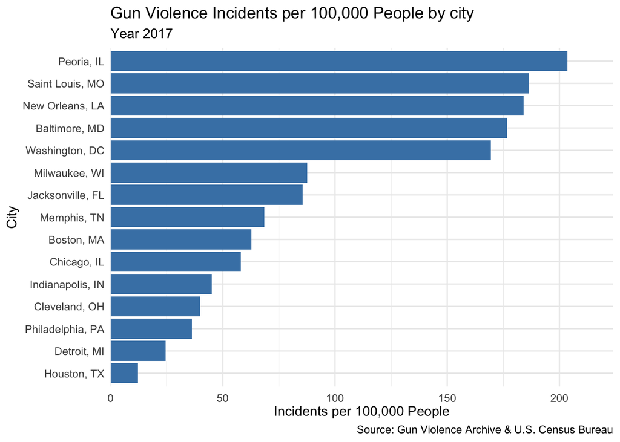

```r
# Convert the city column to a factor with levels ordered by incidents_per_100k
top_15_cities <- top_15_cities |>
  mutate(city_state = factor(city_state, levels = city_state[order(incidents_per_100k, decreasing = FALSE)]))

# Create the bar chart
ggplot(top_15_cities, aes(x = city_state, y = incidents_per_100k)) +
  geom_bar(stat = "identity", fill = "steelblue") +
  scale_y_continuous(expand = expansion(mult = c(0, 0.1))) +
  labs(
    y = "Incidents per 100,000 People",
    x = "City",
    title = "Gun Violence Incidents per 100,000 People by city",
    subtitle = "Year 2017",
    caption = "Source: Gun Violence Archive & U.S. Census Bureau"
  ) +
  theme_minimal() +
  theme(
    axis.text.x = element_text(vjust = 0.5)
  ) +
  coord_flip()
```

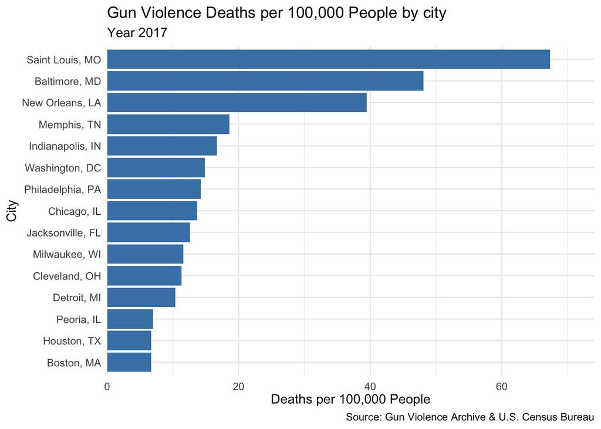

```r
n_killed_2017 <- gun_data_2017 |>
  group_by(geoid) |>
  summarise(n_killed = sum(n_killed), .groups = 'drop')

top_15_cities <- top_15_cities |>
  left_join(n_killed_2017, by = "geoid")

# Calculate gun deaths per 100,000 people
top_15_cities <- top_15_cities |>
  mutate(prop_deaths = (n_killed / count))

# Calculate gun deaths per 100,000 people
top_15_cities <- top_15_cities |>
  mutate(deaths_per_100k = (n_killed / population) * 100000)

top_15_cities <- top_15_cities |>
  mutate(city_state = factor(city_state, levels = city_state[order(deaths_per_100k, decreasing = FALSE)]))

# Create the bar chart
ggplot(top_15_cities, aes(x = city_state, y = deaths_per_100k)) +
  geom_bar(stat = "identity", fill = "steelblue") +
  scale_y_continuous(expand = expansion(mult = c(0, 0.1))) +
  labs(
    y = "Deaths per 100,000 People",
    x = "City",
    title = "Gun Violence Deaths per 100,000 People by city",
    subtitle = "Year 2017",
    caption = "Source: Gun Violence Archive & U.S. Census Bureau"
  ) +
  theme_minimal() +
  theme(
    axis.text.x = element_text(vjust = 0.5)
  ) +
  coord_flip()
```

As we look at the data more granularly, a different picture starts to emerge. While at the state level, Alaska seems to be experiencing the most gun violence, no Alaskan city is within the top 15 most incident-prone cities. Analyzing the top 15 most incident-prone states through the lens of the most deadly, Saint Louis, MO, stands out, with 36% of all gun violence incidents ending in death in 2017. Let’s dive a bit deeper to uncover more insights.

### 4.7.2 Visualization: Correlation plots

With all the additional demographic data from the census dataset, I wanted to see if any of the added features might correlate with the deaths and incidents occurring within our dataset. From here on out, I will continue to look at the top 15 states with the highest levels of gun violence incidents in 2017.

Adding 3 additional features to analyze.

- `rent_percentage`: The proportion of median annual rent cost to the median annual income.
- `home_percentage`: The proportion of median annual mortgage cost to the median annual income.
- `prop_deaths`: The proportion of gun violence incidents that produced a gun violence death

I added these to see if these scores, in addition to any other macroeconomic data, might give us a better signal to correlate with deaths and incidents.

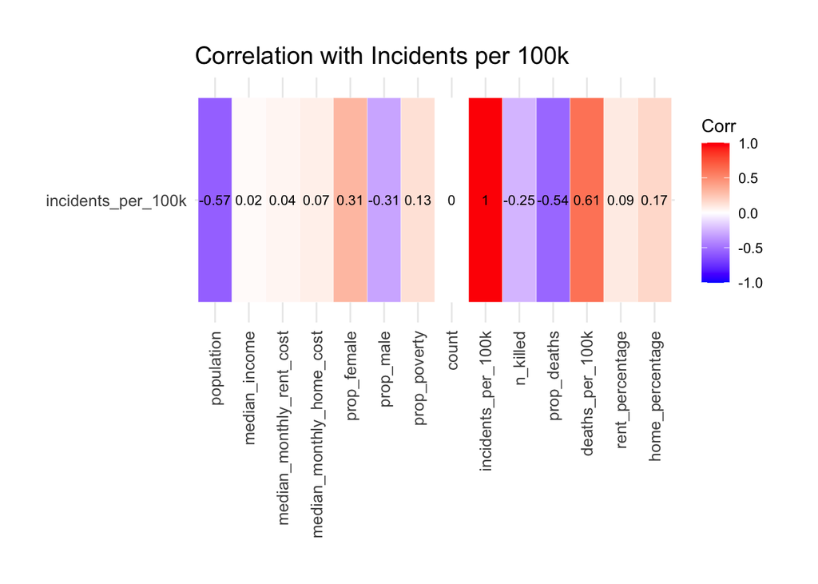

```r
# Adding rent_percentage and home_percentage to top_15_cities
top_15_cities <- top_15_cities |>
  mutate(
    # rent_percentage: The proportion of median annual rent cost to the median annual income
    rent_percentage = (median_monthly_rent_cost * 12) / median_income,

    # home_percentage: The proportion of median annual home cost to the median annual income
    home_percentage = (median_monthly_home_cost * 12) / median_income
  )

# Function to rearrange columns by data type
rearrange_by_data_type <- function(df) {
  # Split the columns by data type
  num_cols <- df |> select(where(is.numeric))
  factor_cols <- df |> select(where(is.factor))
  char_cols <- df |> select(where(is.character))
  logical_cols <- df |> select(where(is.logical))
  date_cols <- df |> select(where(is.Date))

  # Combine the columns back in the desired order
  df_rearranged <- bind_cols(char_cols, factor_cols, date_cols, num_cols, logical_cols, )

  return(df_rearranged)
}

# Apply the function to rearrange columns by data type
top_15_cities <- rearrange_by_data_type(top_15_cities)

# selecting numeric columns to perform correlation matrix on
numeric_columns <- top_15_cities |>
  select(population:home_percentage)

# Calculate the correlation matrix for the selected numeric columns
correlation_matrix <- cor(numeric_columns, use = "complete.obs")

# Extract correlations related to incidents_per_100k and deaths_per_100k
correlation_incidents <- correlation_matrix["incidents_per_100k", ]
correlation_deaths <- correlation_matrix["deaths_per_100k", ]

# Extract the row corresponding to incidents_per_100k
correlation_incidents <- correlation_matrix["incidents_per_100k", ]

# Convert the extracted correlations to a data frame
correlation_incidents_df <- as.data.frame(correlation_incidents)
correlation_incidents_df$variable <- rownames(correlation_incidents_df)
rownames(correlation_incidents_df) <- NULL

# Create a diagonal matrix to visualize with ggcorrplot
diag_matrix <- diag(0, ncol(correlation_matrix))
rownames(diag_matrix) <- colnames(diag_matrix) <- colnames(correlation_matrix)
diag_matrix["incidents_per_100k", ] <- correlation_matrix["incidents_per_100k", ]
diag_matrix[, "incidents_per_100k"] <- correlation_matrix[, "incidents_per_100k"]
diag_matrix <- as.data.frame(diag_matrix)
diag_matrix <- diag_matrix |> select(incidents_per_100k)
diag_matrix <- t(diag_matrix)

# Plot the filtered correlation matrix using ggcorrplot
ggcorrplot(as.matrix(diag_matrix),
           hc.order = FALSE,
           outline.color = "white",
           lab = TRUE,
           lab_size = 3,
           title = "Correlation with Incidents per 100k") +
  theme(
    axis.text.x = element_text(angle = 90, vjust = 0.5, hjust = 1, size = 10),
    axis.text.y = element_text(size = 10),
    plot.title = element_text(size = 15),
    plot.subtitle = element_text(size = 10),
    plot.margin = unit(c(1, 1, 1, 1), "cm")
  ) +
  coord_flip()
```

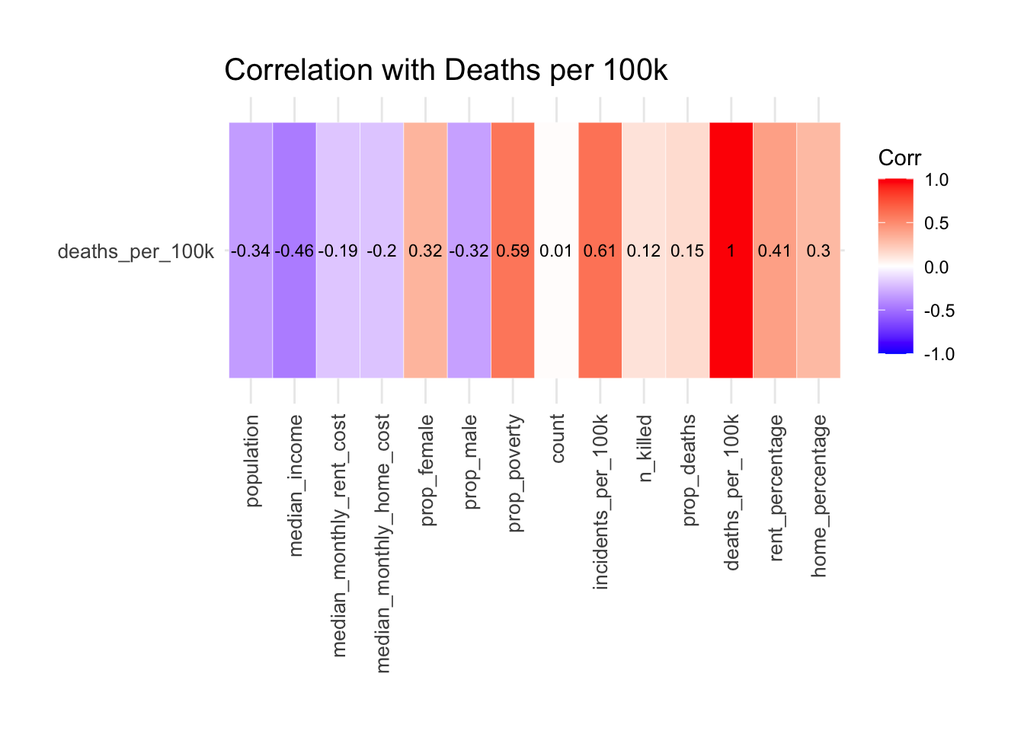

```r
# Convert the extracted correlations to a data frame
correlation_deaths_df <- as.data.frame(correlation_deaths)
correlation_deaths_df$variable <- rownames(correlation_deaths_df)
rownames(correlation_deaths_df) <- NULL

# Create a diagonal matrix to visualize with ggcorrplot
diag_matrix <- diag(0, ncol(correlation_matrix))
rownames(diag_matrix) <- colnames(diag_matrix) <- colnames(correlation_matrix)
diag_matrix["deaths_per_100k", ] <- correlation_matrix["deaths_per_100k", ]
diag_matrix[, "deaths_per_100k"] <- correlation_matrix[, "deaths_per_100k"]
diag_matrix <- as.data.frame(diag_matrix)
diag_matrix <- diag_matrix |> select(deaths_per_100k)
diag_matrix <- t(diag_matrix)

# Plot the filtered correlation matrix using ggcorrplot
ggcorrplot(as.matrix(diag_matrix),
           hc.order = FALSE,
           outline.color = "white",
           lab = TRUE,
           lab_size = 3,
           title = "Correlation with Deaths per 100k") +
  theme(
    axis.text.x = element_text(angle = 90, vjust = 0.5, hjust = 1, size = 10),
    axis.text.y = element_text(size = 10),
    plot.title = element_text(size = 15),
    plot.subtitle = element_text(size = 10),
    plot.margin = unit(c(1, 1, 1, 1), "cm")
  ) +
  coord_flip()
```

When correlating our features with deaths per 100,000 people, we see a different picture. It seems that poverty has a moderate influence on the deadliness of an American city. Our added scores regarding the cost of living are seemingly a function of the median income and/or the proportion of poverty, so I chose to focus on poverty itself to see if we can gain some insight into its effects.

# 5 Function of poverty

## 5.1 Visualization: Scatter plots with linear regression lines

Here, I plotted our incidents per 100,000 people in a scatter plot with a correlation line with respect to the proportion of the population within the city living in poverty.

```r
p <- top_15_cities |>
  ggplot(
    aes(
      x = incidents_per_100k,
      y = prop_poverty
    )
  ) +
  geom_point(
    aes(
      text = paste(
        "City:", city_state,
        "<br>Incidents per 100k:", round(incidents_per_100k, digits = 1),
        "<br>Proportion in Poverty:", percent(prop_poverty, accuracy = 0.1)
        )
      )
    ) +
  # Add a linear regression line for each facet/group, colored blue
  geom_smooth(
    method = "lm", # linear model
    se = FALSE, # standard error visible
    size = 1,
    color = "red"
  )  +
  labs(
    title = "Incidents per 100k by proportion of poverty",
    subtitle = "Top 15 cities in 2017",
    x = "Incidents per 100k",
    y = "Proportion of city population in poverty",
    caption = "Source: Gun Violence Archive & U.S. Census Bureau"
  ) +
    scale_y_continuous(labels = percent, breaks = seq(0, 0.5, by = 0.02)) +

  theme_bw()

# Convert the ggplot2 plot to an interactive plotly plot with custom tooltips
p_plotly <- ggplotly(p, tooltip = "text")

# Manually add the subtitle and caption
p_plotly <- p_plotly |>
  layout(
    title = list(
      text = "Incidents per 100k by proportion of poverty<br><sup>Top 15 cities in 2017</sup>"
    ),
    annotations = list(
      list(
        x = 0,
        y = -0.13,  # Adjust the y position to move the caption up slightly
        text = "Source: Gun Violence Archive & U.S. Census Bureau",
        showarrow = FALSE,
        xref = 'paper',
        yref = 'paper',
        xanchor = 'left',
        yanchor = 'auto',
        xshift = 0,
        yshift = 0,
        font = list(size = 8)
      )
    ),
    margin = list(t = 80, b = 100)  # Add extra margin to accommodate the caption
  )

# Display the interactive plot
p_plotly
```

[interactive chart not shown]

The regression line is nearly flat, which is a direct reflection of the correlation matrix in the previous section.

```r
q <- top_15_cities |>
  ggplot(
    aes(
      x = deaths_per_100k,
      y = prop_poverty
    )
  ) +
  geom_point(
    aes(
      text = paste(
        "City:", city_state,
        "<br>Deaths per 100k:", round(deaths_per_100k, digits = 1),
        "<br>Proportion in Poverty:", percent(prop_poverty, accuracy = 0.1)
        )
      )
    ) +
  # Add a linear regression line for each facet/group, colored blue
  geom_smooth(
    method = "lm", # linear model
    se = FALSE, # standard error visible
    size = 1,
    color = "red"
  )  +
  labs(
    title = "Deaths per 100k by proportion of poverty",
    subtitle = "Top 15 cities in 2017",
    x = "Deaths per 100k",
    y = "Proportion of city population in poverty",
    caption = "Source: Gun Violence Archive & U.S. Census Bureau"
  ) +
  scale_y_continuous(labels = percent, breaks = seq(0, 0.5, by = 0.02)) +
  theme_bw()

# Convert the ggplot2 plot to an interactive plotly plot with custom tooltips
q_plotly <- ggplotly(q, tooltip = "text")

# Manually add the subtitle and caption
q_plotly <- q_plotly |>
  layout(
    title = list(
      text = "Deaths per 100k by proportion of poverty<br><sup>Top 15 cities in 2017</sup>"
    ),
    annotations = list(
      list(
        x = 0,
        y = -0.13,  # Adjust the y position to move the caption up slightly
        text = "Source: Gun Violence Archive & U.S. Census Bureau",
        showarrow = FALSE,
        xref = 'paper',
        yref = 'paper',
        xanchor = 'left',
        yanchor = 'auto',
        xshift = 0,
        yshift = 0,
        font = list(size = 8)
      )
    ),
    margin = list(t = 80, b = 100)  # Add extra margin to accommodate the caption
  )

# Display the interactive plot
q_plotly
```

[interactive chart not shown]

## 5.2 Monte Carlo Methods of Inference

### 5.2.1 Hypothesis

Given the relationship between poverty and gun violence observed in the preliminary analysis, I hypothesize that cities with higher poverty levels experience a greater number of gun violence deaths per 100,000 people. Specifically:

$$H_0: \mu_1 \le \mu_2 \text{ vs. } H_a:
\mu_1 > \mu_2$$

```r
# Divide cities into low and high poverty groups
prop_poverty_threshold <- median(top_15_cities$prop_poverty)
low_poverty_cities <- top_15_cities %>% filter(prop_poverty <= prop_poverty_threshold)
high_poverty_cities <- top_15_cities %>% filter(prop_poverty > prop_poverty_threshold)

val <- round(prop_poverty_threshold * 100, digits = 1)

low_poverty_cities <- low_poverty_cities |>
  select(
    -(1:5),
    -(7:18),
    -(20:21)
    )

high_poverty_cities <- high_poverty_cities |>
  select(
    -(1:5),
    -(7:18),
    -(20:21)
    )

# Stacking data frames
stacked_data <- bind_rows(low_poverty_cities, high_poverty_cities)

stacked_data <- stacked_data %>%
  mutate(Poverty_Level = case_when(
    row_number() <= 8 ~ "Low poverty cities",
    row_number() > 8 ~ "High poverty cities"
  ))

stacked_data <- stacked_data |>
  select(city_state, Poverty_Level, deaths_per_100k)
```

To test this hypothesis, I divided the top 15 cities into low and high poverty groups based on the median proportion (19.8%) of the population living in poverty.

```r
stacked_ft <- flextable(stacked_data) %>%
  set_header_labels(
    city_state = "City, State",
    Poverty_Level = "Poverty Level",
    deaths_per_100k = "Deaths per 100k"
  ) %>%
  add_header_row(values = "Table 6: 15 Deadliest Cities by Poverty Rate (2017)", colwidths = 3) %>%
  padding(padding = 3, part = "all") %>%
  add_footer_lines(values = "Source: Gun Violence Archive & U.S. Census Bureau") %>%
  theme_vanilla() %>%
  autofit()

stacked_ft
```

| Table 6: 15 Deadliest Cities by Poverty Rate (2017) City, State | Table 6: 15 Deadliest Cities by Poverty Rate (2017) Poverty Level | Table 6: 15 Deadliest Cities by Poverty Rate (2017) Deaths per 100k |
| --- | --- | --- |
| Chicago, IL | Low poverty cities | 13.687017 |
| Washington, DC | Low poverty cities | 14.872299 |
| Jacksonville, FL | Low poverty cities | 12.609055 |
| Houston, TX | Low poverty cities | 6.695365 |
| Cleveland, OH | Low poverty cities | 11.293136 |
| Boston, MA | Low poverty cities | 6.660817 |
| Indianapolis, IN | Low poverty cities | 16.702767 |
| Peoria, IL | Low poverty cities | 6.983803 |
| Baltimore, MD | High poverty cities | 48.080336 |
| Milwaukee, WI | High poverty cities | 11.603766 |
| New Orleans, LA | High poverty cities | 39.414501 |
| Memphis, TN | High poverty cities | 18.553133 |
| Saint Louis, MO | High poverty cities | 67.330016 |
| Philadelphia, PA | High poverty cities | 14.206925 |
| Detroit, MI | High poverty cities | 10.375197 |

Source: Gun Violence Archive & U.S. Census Bureau

### 5.2.2 Visualization: Comparison of Gun Violence Deaths

The first visualization compares the number of gun violence deaths per 100,000 people between low poverty and high poverty cities. This box plot displays the distribution of gun violence deaths for both groups.

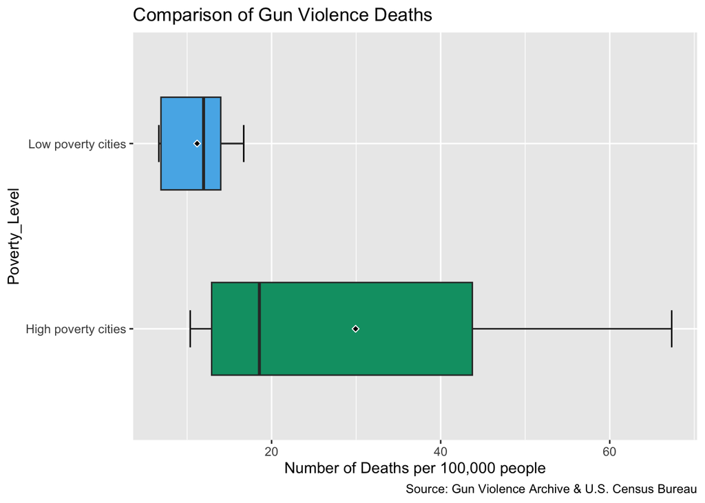

```r
stacked_data |>
  ggplot(
    aes(
      x = Poverty_Level,
      y = deaths_per_100k,
      fill = Poverty_Level
    )
  ) +
  stat_boxplot(geom = "errorbar", width = 0.2, coef = 1.5) +
  stat_boxplot(geom = "boxplot", width = 0.5, coef = 1.5,
               outlier.shape = 8) +
  stat_summary(fun = "mean", geom = "point", shape = 23, fill = "black",
               color = "white") +
  scale_fill_manual(values = c("#009E73", "#56B4E9")) +
  coord_flip() +
  labs(
    y = "Number of Deaths per 100,000 people",
    title = "Comparison of Gun Violence Deaths",
    caption = "Source: Gun Violence Archive & U.S. Census Bureau"
    ) +
  theme(legend.position = "none")
```

**Key observations from the box plot**:

**Low Poverty Cities**: The box plot shows a relatively narrow range of deaths per 100,000 people, indicating less variability within this group. The median number of deaths is lower, and the whiskers suggest fewer extreme values.

**High Poverty Cities**: The box plot for high poverty cities reveals a much wider range of deaths per 100,000 people, with a higher median and more variability. This indicates a greater spread of gun violence incidents in these cities, including some with very high death rates.

This visualization supports the hypothesis that cities with higher poverty levels experience more gun violence deaths, highlighting the need to explore further the impact of socioeconomic factors on gun violence.

### 5.2.3 Visualization: Empirical Density Curves and Dot Plot

The second visualization provides an empirical density curve and dot plot comparing the number of gun violence deaths per 100,000 people between low poverty and high poverty cities. This visualization helps to highlight the distribution and density of gun violence deaths in both groups.

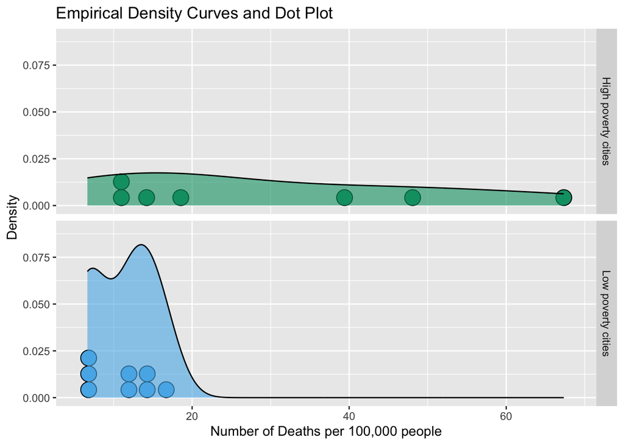

```r
stacked_data |>
  ggplot(aes(x = deaths_per_100k,
             fill = Poverty_Level)) +
  geom_dotplot() +
  geom_density(color = "black", alpha = 0.6) +
    scale_fill_manual(values = c("#009E73", "#56B4E9")) +
  facet_grid(Poverty_Level ~ .) +
    labs(x = "Number of Deaths per 100,000 people",
         title = "Empirical Density Curves and Dot Plot",
         y = "Density") +
  theme(legend.position = "none") +
  ylim(0, 0.09)
```

**Key observations from the density curves and dot plot**:

**Low Poverty Cities**: The density curve for low poverty cities shows a higher peak, indicating that most cities in this group have a lower number of deaths per 100,000 people. The dot plot reinforces this by showing a concentration of points at lower death rates.

**High Poverty Cities**: The density curve for high poverty cities is relatively flat, suggesting a wider spread of death rates within this group. The dot plot shows that these cities have a broader range of gun violence death rates, with some cities experiencing significantly higher death rates.

### 5.2.4 Assumption Checking for T-Tests

#### 5.2.4.1 Checking Normality

Before proceeding with the t-test, it is essential to verify if the data follows a normal distribution. The Shapiro-Wilk test was used to assess the normality of the gun violence death rates per 100,000 people in both low and high poverty cities.

```r
# Check for normality
shapiro_low <- shapiro.test(stacked_data$deaths_per_100k[stacked_data$Poverty_Level == "Low poverty cities"])
shapiro_high <- shapiro.test(stacked_data$deaths_per_100k[stacked_data$Poverty_Level == "High poverty cities"])

# Extract the results into a data frame
shapiro_low_df <- data.frame(
  Statistic = shapiro_low$statistic,
  p_value = shapiro_low$p.value,
  Method = shapiro_low$method,
  Data = "Low poverty cities"
)

shapiro_high_df <- data.frame(
  Statistic = shapiro_high$statistic,
  p_value = shapiro_high$p.value,
  Method = shapiro_high$method,
  Data = "High poverty cities"
)

shapiro_low_df |> flextable() |>
  set_caption("Result from Shapiro-Wilk Normality Test for Low poverty cities") |>
  padding(padding = 3, part = "all") %>%
  theme_vanilla() %>%
  autofit()
```

Result from Shapiro-Wilk Normality Test for Low poverty cities

| Statistic | p_value | Method | Data |
| --- | --- | --- | --- |
| 0.887914 | 0.2237709 | Shapiro-Wilk normality test | Low poverty cities |

```r
shapiro_high_df |> flextable() |>
  set_caption("Result from Shapiro-Wilk Normality Test for High poverty cities") |>
  padding(padding = 3, part = "all") %>%
  theme_vanilla() %>%
  autofit()
```

Result from Shapiro-Wilk Normality Test for High poverty cities

| Statistic | p_value | Method | Data |
| --- | --- | --- | --- |
| 0.8616306 | 0.1565586 | Shapiro-Wilk normality test | High poverty cities |

**Results**:

**Low Poverty Cities**: The Shapiro-Wilk test statistic is 0.89 with a p-value of 0.22, indicating that we do not reject the null hypothesis of normality. Therefore, the data for low poverty cities can be considered normally distributed.

**High Poverty Cities**: The Shapiro-Wilk test statistic is 0.86 with a p-value of 0.16, indicating that we do not reject the null hypothesis of normality. Thus, the data for high poverty cities can also be considered normally distributed.

Both groups meet the normality assumption necessary for conducting the t-test. However, it’s important to note that with a small sample size (n = 15), the power of the normality test may be limited, and the results should be interpreted with caution.

#### 5.2.4.2 Checking Equal Variance

Next, I assess the assumption of equal variance between the two groups using the standard deviations and variances of gun violence death rates per 100,000 people.

```r
# Calculating standard deviations and variances for each group
stacked_data |>
  group_by(Poverty_Level) |>
  summarize(Mean = mean(deaths_per_100k),
            n = n(),
            SD = sd(deaths_per_100k),
            Variance = var(deaths_per_100k)) |>
  flextable() |>
  colformat_double(digits = 3) |>
  padding(padding = 3, part = "all") %>%
  theme_vanilla() %>%
  autofit()
```

| Poverty_Level | Mean | n | SD | Variance |
| --- | --- | --- | --- | --- |
| High poverty cities | 29.938 | 7 | 22.034 | 485.507 |
| Low poverty cities | 11.188 | 8 | 3.975 | 15.802 |

**Results**:

**High Poverty Cities**: The mean death rate is 29.9 with a standard deviation of 22 and a variance of 485.507.

**Low Poverty Cities**: The mean death rate is 11.2 with a standard deviation of 4 and a variance of 15.8.

The results show that the variances are not equal, with high poverty cities having a significantly larger variance than low poverty cities. Therefore, the assumption of equal variance is violated.

Given these results, we will use Welch’s t-test, which does not assume equal variances, to compare the gun violence death rates between low and high poverty cities.

### 5.2.5 Welch’s t-test

```r
# Perform Welch's t-test
welch_t_result <- t.test(deaths_per_100k ~ Poverty_Level, data = stacked_data, alternative = "greater", var.equal = FALSE)

# Extract the results into a data frame
welch_t_result_df <- data.frame(
  Statistic = welch_t_result$statistic,
  t_df = welch_t_result$parameter,
  p_value = welch_t_result$p.value,
  Alternative = welch_t_result$alternative,
  Estimate = welch_t_result$estimate,
  Lower_CI = welch_t_result$conf.int[1],
  Upper_CI = welch_t_result$conf.int[2]
)

# Convert the data frame to a flextable
welch_t_result_ft <- welch_t_result_df |>
  flextable() |>
  set_caption("Results of Welch's t-test comparing rates of gun violence deaths between the low poverty cities and high poverty cities groups.") |>
  padding(padding = 3, part = "all") %>%
  theme_vanilla() %>%
  autofit()

# Print the flextable
welch_t_result_ft
```

Results of Welch's t-test comparing rates of gun violence deaths between the low poverty cities and high poverty cities groups.

| Statistic | t_df | p_value | Alternative | Estimate | Lower_CI | Upper_CI |
| --- | --- | --- | --- | --- | --- | --- |
| 2.219969 | 6.342214 | 0.03290321 | greater | 29.93770 | 2.494976 | Inf |
| 2.219969 | 6.342214 | 0.03290321 | greater | 11.18803 | 2.494976 | Inf |

**Results**:

- The Welch’s t-test statistic is 2.219969, and the degrees of freedom (t_df) is 6.342214.
- The p-value is 0.03290321, indicating a statistically significant difference in death rates between the two groups.
- The alternative hypothesis specifies that the death rate is greater in high poverty cities.
- The mean estimate for high poverty cities is 29.9, while for low poverty cities, it is 11.2.
- The confidence interval for the difference in means ranges from 2.494976 to infinity.

These results indicate that gun violence death rates are significantly higher in high poverty cities compared to low poverty cities, supporting the hypothesis that poverty levels are associated with increased gun violence deaths.

### 5.2.6 Permutation Testing

To further validate the results of the Welch’s t-test, we performed a permutation test. This method helps to assess the robustness of our findings by generating a distribution of t-statistics under the null hypothesis through 1000 random permutations.

```r
# Set the number of permutations
nperms <- 1000

# Initialize a vector to store the permuted test statistics
permTs <- vector(length = nperms)

# Calculate the observed Welch's t-test statistic
observed_t <- t.test(
  deaths_per_100k ~ Poverty_Level,
  data = stacked_data,
  alternative = "greater",
  var.equal = FALSE
  )$statistic

# Perform the permutation test
set.seed(1986) # For reproducibility

for (p in 1:nperms) {
  permuted_data <- stacked_data %>%
    mutate(
      Poverty_Level = sample(Poverty_Level, replace = FALSE)
      )
  permTs[p] <- t.test(
    deaths_per_100k ~ Poverty_Level,
    data = permuted_data,
    alternative = "greater",
    var.equal = FALSE
    )$statistic
}

# Calculate the p-value
p_value <- mean(permTs >= observed_t)

# Create a data frame for the p-value result
p_value_df <- data.frame(
  Statistic = c("Observed t-statistic", "Permutation p-value"),
  Value = c(round(observed_t, 2), round(p_value, 3))
)

# Display the p-value result using flextable
p_value_ft <- p_value_df |>
  flextable() |>
  set_caption("Permutation Test Results") |>
  padding(padding = 3, part = "all") %>%
  theme_vanilla() %>%
  autofit()

# Print the flextable
p_value_ft
```

Permutation Test Results

| Statistic | Value |
| --- | --- |
| Observed t-statistic | 2.220 |
| Permutation p-value | 0.011 |

The permutation test p-value is 0.011, indicating that the observed t-statistic is rare under the null hypothesis.

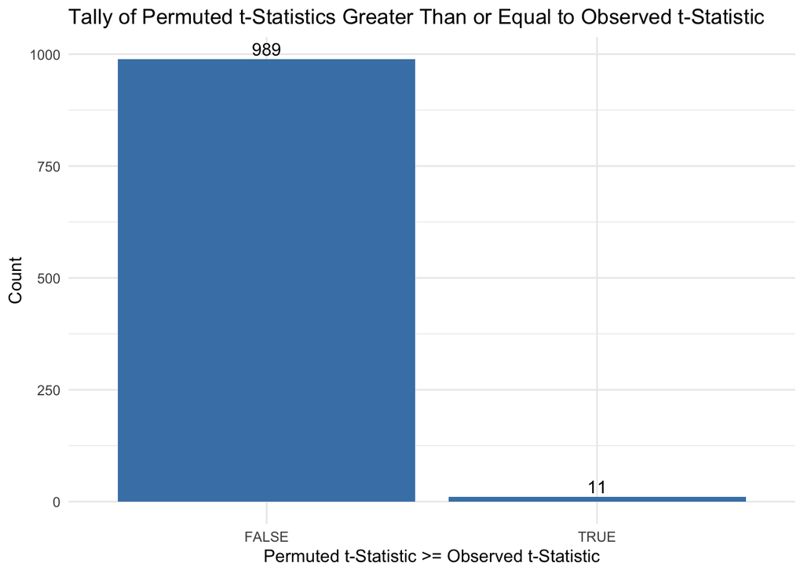

```r
# Tally up
tally_results <- janitor::tabyl(permTs >= observed_t)

# Convert to a data frame for plotting
tally_df <- as.data.frame(tally_results)

# Create a bar plot to visualize the tally results
ggplot(tally_df, aes(x = `permTs >= observed_t`, y = n)) +
  geom_bar(stat = "identity", fill = "steelblue") +
  geom_text(aes(label = n), vjust = -0.3) +
  labs(
    title = "Tally of Permuted t-Statistics Greater Than or Equal to Observed t-Statistic",
    x = "Permuted t-Statistic >= Observed t-Statistic",
    y = "Count"
  ) +
  theme_minimal()
```

The bar plot visualizes the tally of permutations greater than or equal to the observed t-statistic, reinforcing the significance of our original t-test results.

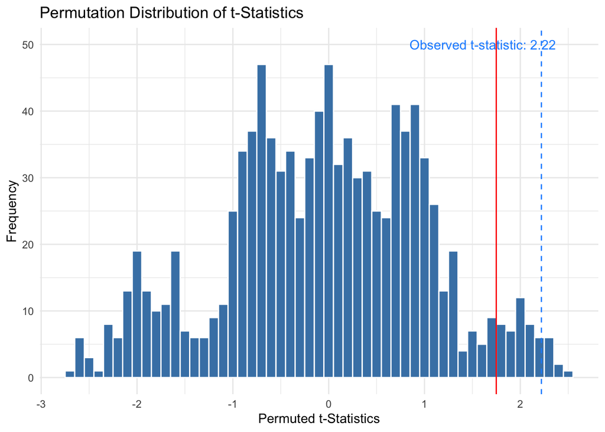

```r
# Visualize the permutation distribution
perm_df <- data.frame(permTs = permTs)

max_y <- max(table(cut(permTs, breaks = seq(min(permTs), max(permTs), by = 0.1)))) + 2


ggplot(perm_df, aes(x = permTs)) +
  geom_histogram(binwidth = 0.1, fill = "steelblue", color = "white") +
  geom_vline(aes(xintercept = observed_t), color = "dodgerblue",  linetype = "dashed") +
  geom_vline(xintercept = quantile(permTs, probs = 0.95), color = "red") +
  theme_minimal() +
  labs(title = "Permutation Distribution of t-Statistics",
       x = "Permuted t-Statistics",
       y = "Frequency") +
  annotate("text", x = observed_t, y = max_y,
           label = paste("Observed t-statistic:", round(observed_t, 2)), color = "dodgerblue", hjust = 0.9) +
  theme_minimal()
```

The histogram of permuted t-statistics shows the distribution of t-values generated from the permutations.

**Statistical Decision**

Given the evidence from Welch’s t-test and the permutation test, we reject the null hypothesis ($H_0: \mu_1 \le \mu_2$) in favor of the alternative hypothesis ($H_a: \mu_1 > \mu_2$). This decision is supported by:

- A p-value of 0.0329 from Welch’s t-test, which is less than the common alpha level of 0.05.
- A permutation p-value of 0.011, indicating that the observed t-statistic is unlikely to occur by chance.

**Conclusion**: There is statistically significant evidence to conclude that cities with higher poverty levels experience higher gun violence death rates compared to cities with lower poverty levels.

This analysis underscores the critical impact of socioeconomic factors on gun violence and highlights the need for targeted interventions in high poverty areas to reduce gun violence deaths.

## 5.3 Bootstrapping

To further analyze the data, we performed a bootstrapping procedure to estimate the distribution of the median number of deaths per 100,000 people in high poverty cities. Bootstrapping allows us to generate multiple samples from the original dataset and compute the statistic of interest, providing a robust estimate of its distribution.

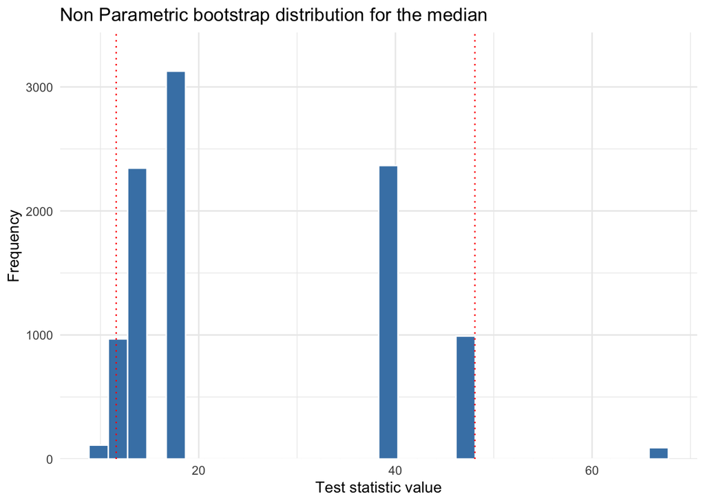

```r
high_poverty <- stacked_data |>
  filter(Poverty_Level == "High poverty cities")

# Number of bootstrap samples
B <- 10000

# Instantiating matrix for bootstrap samples
boots <- matrix(NA, nrow = nrow(high_poverty), ncol = B)

# Sampling with replacement B times
for(b in 1:B) {
boots[, b] <- high_poverty |>
  slice_sample(prop = 1, replace = TRUE) |>
  dplyr::pull(deaths_per_100k)
}

# Instantiating vector for bootstrap medians
boot_medians <- vector(length = B)

# Calculating medians for bootstrap samples
for(b in 1:B) {
boot_medians[b] <- median(boots[, b])
}

tibble(Median = boot_medians) |>
  ggplot(aes(x = Median)) +
  geom_histogram(fill = "steelblue", color = "white") +
  scale_y_continuous(expand = expansion(mult = c(0, 0.1))) +
  labs(title = "Non Parametric bootstrap distribution for the median",
       x = "Test statistic value",
       y = "Frequency") +
  geom_vline(xintercept = quantile(boot_medians, probs = c(0.025, 0.975)), color = "red", linetype = "dotted") +
  theme_minimal()
```

**Results**:

- The histogram shows the distribution of bootstrap medians.
- The vertical dotted lines represent the 2.5th and 97.5th percentiles of the bootstrap distribution, providing a 95% confidence interval for the median.

```r
# Estimating the standard error
standard_error <- sd(boot_medians)

# Calculating the 95% confidence interval
confidence_interval <- quantile(boot_medians, probs = c(0.025, 0.975))

# Create a data frame for the results
results_df <- data.frame(
  Statistic = c("Standard Error", "2.5th Percentile", "97.5th Percentile"),
  Value = c(standard_error, confidence_interval[1], confidence_interval[2])
)

# Display the results using flextable
library(flextable)

results_ft <- results_df |>
  flextable() |>
  set_caption("Bootstrap Estimates for the Median") |>
  padding(padding = 3, part = "all") %>%
  theme_vanilla() |>

  autofit()

# Print the flextable
results_ft
```

Bootstrap Estimates for the Median

| Statistic | Value |
| --- | --- |
| Standard Error | 13.35475 |
| 2.5th Percentile | 11.60377 |
| 97.5th Percentile | 48.08034 |

**Bootstrap Confidence Interval Findings**:

We are 95% confident that at least half of the cities with high poverty rates will experience a death rate from gun violence between 11.6 and 48 deaths per 100,000 people.

# 6 Conclusion

Gun ownership, legislation, and violence in America have always been complex and polarizing topics. Although gun ownership is woven into the fabric of the American identity through the Constitution and is seen as an essential right, that right is viewed by some as conflicting with efforts to solve the problem of gun violence.

This analysis gets closer to untangling some of the mystery behind America’s gun violence issues, but there is still more work to be done. Many more features could be added to get a better sense of what is causing a lethal increase in gun violence deaths in America. With more time and research, we may be able to reach a consensus on how to legislate and deal with the issue.

I personally did not choose this project and had no preconceived notions about what evidence I would find, if any at all. I simply let the data lead my line of questioning. While I intuited that poverty had something to do with gun violence, I didn’t know to what extent. I also did not anticipate the noticeable disparity between its effects on gun violence incidents versus deaths. Through this exercise, it became clear to me that the perspective by which we view the legislation of gun laws is often flawed. In this analysis, gun violence deaths are clearly a dependent variable, or an outcome. They are a function of another feature or set of features of American culture. Trying to solve a problem by focusing on the output instead of the input seems to only perpetuate the issue.

Moreover, through this process and generally looking over some of the previously cited data regarding gun ownership in this country, an interesting pattern emerged that seemed worth exploring. I noticed that many of the states with the deadliest cities had some of the very lowest rates of gun ownership in the country. Despite this being anecdotal, it is a curious question that deserves a solid answer. The devil is in the details, and this multifaceted problem has no shortage of them.

Regarding the statistical significance of poverty as a driver of lethality among states, one might posit that a lack of healthcare infrastructure in impoverished communities could be consequential to health outcomes vis-à-vis gun violence. Poor hospitals, a lack of hospitals, or poor emergency response times could be factors worth examining when thinking about how to improve the situation. Other potential social and psychological factors may be helpful but arduous to collect or rely on for accuracy. Furthermore, they may be clouded by ambiguity and not easily stated.

Being from Baltimore, Maryland, the second deadliest city in America in 2017, it is hard to see the poverty and violence. Knowing that right around the corner, my fellow Americans are residing in a war zone is unsettling, to say the least. I would personally like to see more careful analysis and concerted effort among legislators to pinpoint effective ways to ameliorate gun violence in America. Only through thorough research, open dialogue, and targeted interventions can we hope to make meaningful progress in addressing this critical issue.